# MYO-II / Paper A — Které části intenzitního spektra ENMO nesou longitudinální změnu? (revize A07)

Veronika Balounová

Vytvořeno: **2026-10-13**; revize A07: **2026-10-16** Naposledy aktualizováno **2026-10-16

# 1 Souhrn

**Předem stanovený verdikt lokalizace (E3, ověřená invariance):**

- **M18:** žádný doklad lokální odchylky; hladká redistribuce k vyšším intenzitám
- **M3:** žádný doklad lokální odchylky; hladká redistribuce k vyšším intenzitám
- **M6:** žádný doklad lokální odchylky; hladká redistribuce k vyšším intenzitám

Kde leží změna? Simultánní 95% konfidenční množiny pro {změna > 0} (mg)

| Estimand | Návštěva | Vnitřní množina (jistě > 0) | Vnější množina (možná > 0) |
| --- | --- | --- | --- |
| E1 biny | M3 | 90–300; 325–400 | 20–400 |
| E1 biny | M6 | 80–240 | 20–400 |
| E1 biny | M18 | 120–260 | 20–400 |
| E1 kumulativní | M3 | T30–T375 | T20–T400 |
| E1 kumulativní | M6 | T20–T200 | T20–T400 |
| E1 kumulativní | M18 | T70–T280 | T20–T400 |
| E2 biny | M3 | 90–400 | 20–>=400 |
| E2 biny | M6 | 80–240; 375–400 | 20–>=400 |
| E2 biny | M18 | 140–260 | 20–>=400 |
| E2 kumulativní | M3 | T30–T350 | T20–T400 |
| E2 kumulativní | M6 | T20–T220 | T20–T400 |
| E2 kumulativní | M18 | T70–T325 | T20–T400 |

**Pozor:** Simultánní pásy, ze kterých tyto množiny vycházejí, nejsou kalibrované pro každý bin zvlášť. Simulace se skutečným nullem kalibruje jen pravidlo „hrbu“ o ≥ 2 binech. Množiny pro M18 (n = 39) berte se zvláštní opatrností.

## Klíčová sdělení pro klinického čtenáře

Sdělení popisují ostrý běh z 2026-10-14 (B = 2000; md5 masteru je v příloze o reprodukovatelnosti), revidovaný 2026-10-16 (A07; skripty 07–10, B = 2000). Sdělení 4–6 se v revizi změnila, sdělení 1–3 a 7 zůstala beze změny.

- Odhady, intervaly spolehlivosti (IS), rozsahy a procenta se do textu dosazují z uložených výsledků při renderování reportu.
- Slovní formulace byly zkontrolovány proti tomuto běhu. Pokud se analýza spustí nad jiným vstupem, je nutné ověřit, že formulace stále odpovídají číslům.
1. **Pacienti jsou zřetelně aktivnější a zisk trvá i v M18.**
   - Čas nad 100 mg vzrostl o 20,9 (95% IS 11,6 až 31,0) min/den v M3 a o 21,0 (95% IS 11,5 až 31,0) min/den v M6.
   - V M18 byl stále vyšší o 16,8 (95% IS 6,8 až 26,5) min/den. Odhad pro M18 předpokládá chybění náhodné vzhledem k pozorovaným datům (MAR) a výpadek do M18 je informativní (viz analýza tipping point).
   - Výchozí medián byl 51 min/den, relativní nárůsty tedy činí +35 %, +36 % a +28 %.
2. **Žádný doklad, že by změnu neslo konkrétní pásmo intenzity.** Denní rozdělení intenzit se plynule naklápí k vyšším zrychlením:
   - podíl dne pod 20 mg klesá;
   - biny nízké intenzity (pod ~100 mg) ztrácejí relativní podíl;
   - biny vyšší intenzity relativní podíl získávají, a to tím více, čím vyšší je intenzita.

   Předem stanovený test tvaru nenašel lokální odchylku při žádné návštěvě a výsledek se nezměnil v žádné kontrole invariance.

**Jak report číst.**

- Tři otázky se zodpovídají odděleně, každá vlastním předem stanoveným estimandem:
  - **E1:** kde přibývá čas, v absolutních minutách/den na 10 mg;
  - **E2:** kde je relativní nárůst největší, jako poměr průměrů;
  - **E3:** zda se mění *tvar* rozdělení intenzit nad rámec hladkého posunu.
- Jen E3 může podložit tvrzení o konkrétním informativním intervalu.
- Poloha maxima závisí na estimandu, maxima se proto neprezentují jako prahové body.

# 2 Revize A07: co se změnilo

## Souhrn

Revize zpracovala pět návrhů (A–E) z `MYO_A07_narhy_na_zmeny.txt`. U každého se nejdřív posoudilo, zda je statisticky opodstatněný; rozhodnutí jsou v `docs/261016_A07_critical_review.md`.

- **Beze změny:** primární analýza, její estimandy (E1–E4), populace, prahy, definice binů, modely a všechna jejich čísla. Validační skript je reprodukuje s přesností 10⁻⁶ (R9).
- **Změněno:** figura popisného profilu (A), estimand heterogenity a jeho interpretace (B) a výklad figury tvaru (C).
- **Doplněno:** kontroly robustnosti testu tvaru (C), párová srovnání návštěv (D) a exploratorní modely podtypů adjustované na závažnost s klinickými daty mimo master (E).

Přehled změn revize A07

| Položka | Typ | Co se změnilo | Vliv na závěry |
| --- | --- | --- | --- |
| Popisný profil (BINY) | figura nahrazena | osa y = min/den na 10 mg místo surových min/den v binu; původní figura ponechána jako panel A srovnání | zdánlivý lokální vrchol 120–140 mg mizí; profil je monotónní |
| F6 heterogenita | nový estimand, nová figura | koncentrace kladných zisků (s minimem při stejných ziscích a IS); index net/gross; panely nízké/vysoké intenzity; původní podíl na čistém zisku zvlášť s označením nestabilních buněk | „menšina silných responderů ve vysokých intenzitách“ nahrazeno „široká co do směru, nerovnoměrná co do velikosti v podobné míře v celém spektru“ |
| Klíčové sdělení 5, H3 | text revidován | nový estimand a formulace | viz F6 |
| F3 (tvar E3) | figura překreslena, text revidován | zobrazena hladká křivka každé návštěvy; výklad panelů A/B a kritéria odchylky vypsána; čísla totožná | žádný |
| Robustnost E3 | doplněná analýza | df 1–5, fit vážený šířkou, mřížka 20 mg, biny do 400 mg; důkaz invariance; plasmode pro df | „bez lokální odchylky“ platí pro df 3, 4 i 5, vážený fit a obě alternativní mřížky |
| Tvar mezi návštěvami | doplněná analýza | párové testy sklonu a hladké křivky (3 df) M3/M6/M18, Holm; společný vzorek; tabulka časování a sezóny | rozdíl časné vs pozdější fáze statisticky nepodložen (H4 zůstává hypotézou) |
| Klíčové sdělení 4, H4 | text revidován | odkaz na formální testy | opatrnější formulace |
| Podtypy | doplněná analýza (exploratorní) | modely ΔT100, sklonu a ΔIG s adjustací na ph_VAS (hlavní) / MMT8; kontrola konstruktu a kolinearity; F7 beze změny; doplněna F7b | IMNM menší objemový zisk (MMT8 ho nevysvětluje, IS širší); doklad rozdílu tvaru chybí; doplněna H5 |
| Validace | doplněna | skript 10 (R1–R10) | viz záložka validace |

# 3 Výzkumné otázky a estimandy

| Kód | Otázka | Estimand | Analyzovaný soubor |
| --- | --- | --- | --- |
| E1 | Kde ve spektru přibývá čas? | Δ průměrných min/den na 10 mg, Mx − M0 (MMRM, nestrukturovaná kovariance) | všechna měření (MAR) |
| E2 | Kde je relativní změna největší? | poměr marginálních průměrů Mx/M0 ze stejného MMRM | všechna měření (MAR) |
| E3 | Mění se tvar nad rámec hladkého posunu? | průměrná párová změna clr 21dílné 24h kompozice; reziduum od nullu z přirozeného splinu v log intenzitě | kompletní páry |
| E4 | Je změna velká vzhledem ke své variabilitě? | dz = průměrná Δ / SD(Δ) | kompletní páry |
| CUM | Doplňková, překrývající se reprezentace | E1/E2 pro 24 kumulativních prahů | všechna měření |

Z těchto dat lze odhadnout:

- změnu na úrovni skupiny (E1/E2);
- přesnost změny na úrovni skupiny (bootstrapová SE);
- prevalenci expozice (pokrytí).

Z master datasetu **nelze odhadnout**:

- individuální test-retest reliabilitu (ICC/SEM/SDC); k té jsou potřeba denní výstupy GGIR (`part2_daysummary`);
- klinickou prediktivní hodnotu, která je mimo rozsah práce.

# 4 Zdroj dat, kohorta, QC a chybějící data

Tok kohortou

| Krok | n |
| --- | --- |
| Záznamy v masteru | 251 |
| Záznamy způsobilé po QC | 251 |
| Záznamy hlavních návštěv (M0–M18) | 217 |
| Pacienti v hlavní analýze | 71 |
| Exploratorní záznamy (M30–M60) | 34 |

**Co ukazuje.** Kolik záznamů a pacientů vstupuje do analýzy.

- Všechny záznamy prošly QC přístroje včetně kalibrační chyby pod 0,01 g.
- Hlavní analýza používá návštěvy M0–M18. M30–M60 se ukazují jen deskriptivně, protože obsahují málo pacientů.

Kontroly integrity master datasetu (PASS / WARN / FAIL / INFO)

| ID | Kontrola | Stav | Detail (technický výpis) |
| --- | --- | --- | --- |
| D1 | Jedinečná kombinace pacient × návštěva | PASS | 251 records |
| D2 | Způsobilost po QC | PASS | 0 of 251 not eligible |
| D3 | Hlavní vzorek (M0–M18) | INFO | 217 recordings / 71 patients; M0=63, M3=52, M6=57, M18=45 |
| D4 | Kompletní páry s M0 | INFO | M3=47, M6=52, M18=39 |
| D5 | Pacienti bez M0 | WARN | 8 patients (enter LMM, not paired analyses) |
| D6 | Úplná mřížka prahů | PASS | 20,30,40,50,60,70,80,90,100,110,120,140,160,180,200,220,240,260,280,300,325,350,375,400 |
| D7 | Exkluzivní biny | PASS | 23 bounded bins 20-400 mg; open >400 bin present: FALSE |
| D8 | Monotonie kumulativních prahů | PASS | 0 violations |
| D9 | bin = T_dolní − T_horní | PASS | max &#124;error&#124; = 0.00e+00 |
| D10 | součet binů = T20 − T400 | PASS | max &#124;error&#124; = 0.00e+00 |
| D11 | minutes_per_10mg konzistentní | PASS | max &#124;error&#124; = 2.84e-14 |
| D12 | Nezáporné biny | PASS | 0 negative |
| D13 | Přesné nuly vs téměř nuly v binech | INFO | max exact-zero share 6.5%; bins with >50% <=1 min/day: 260,280,300,325,350,375 |
| D14 | Validní dny (hlavní vzorek) | WARN | 3d=1, 4d=6, 5d=13, 6d=172, 7d=25 |
| D15 | Měsíc/sezóna ze start_time | PASS | season/month taken from local start_time (acc_date is shifted by 1 day in some records; not used) |
| D16 | Kódování podtypů | WARN | undefined codes (excluded from subtype analyses): NA |
| D18 | Měsíce od M0: medián (rozsah) | WARN | M3 3.2 (2.0-6.0); M6 6.6 (4.3-9.4); M18 19.5 (16.5-21.8) |
| D19 | Sezóna × návštěva | INFO | M0:Winter:6; M0:Spring:25; M0:Summer:14; M0:Autumn:18; M18:Winter:11; M18:Spring:14; M18:Summer:10; M18:Autumn:10; M3:Winter:10; M3:Spring:9; M3:Summer:15; M3:Autumn:18; M6:Winter:16; M6:Spring:15; M6… |

**Jak číst.**

- Každý řádek je automatická kontrola konzistence master datasetu.
- **PASS** znamená, že data splňují očekávanou aritmetiku. Například čas v exkluzivním binu se rovná rozdílu dvou sousedních kumulativních prahů a čas nad vyšším prahem nikdy nepřesáhne čas nad nižším.
- **WARN** označuje vlastnosti, které data nezneplatňují, ale je třeba je zohlednit při interpretaci: pacienti bez výchozího měření, záznamy s méně než 5 validními dny, překrývající se časová okna M3/M6 a nedefinované kódy podtypů.

**Hodnocení.** Žádný výsledek FAIL, data jsou tedy vnitřně konzistentní a odvozené exkluzivní biny jsou přesné.

**Klinicky významné WARN: časování návštěv.**

- M3 byla zaznamenána 2–6 měsíců po M0 a M6 4–9 měsíců po M0, obě okna se tedy částečně překrývají.
- Rozdíly „M3 vs M6“ je proto třeba číst jako *časná vs pozdější kontrola*, ne jako přesné časové body 3 a 6 měsíců.
- Citlivostní analýza se skutečným časem od výchozího měření dala stejný obraz.

Pozorované vzorce návštěv (hlavní návštěvy)

| Vzorec návštěv | Pacienti |
| --- | --- |
| M0-M3-M6-M18 | 34 |
| M0-M3-M6 | 11 |
| M0 | 8 |
| M0-M6-M18 | 4 |
| M0-M6 | 3 |
| M3-M6-M18 | 3 |
| M0-M3 | 2 |
| M18 | 2 |
| M0-M18 | 1 |
| M3 | 1 |
| M3-M6 | 1 |
| M6-M18 | 1 |

**Co ukazuje.** Které návštěvy každý pacient absolvoval. Všechny čtyři hlavní návštěvy má jen zhruba polovina pacientů.

**Proč na tom záleží.** Smíšený model (MMRM) využívá každé dostupné měření a zůstává platný, pokud chybění závisí na tom, co už bylo pozorováno (MAR). Jednodušší párová srovnání (M0 vs Mx) používají jen pacienty s oběma návštěvami.

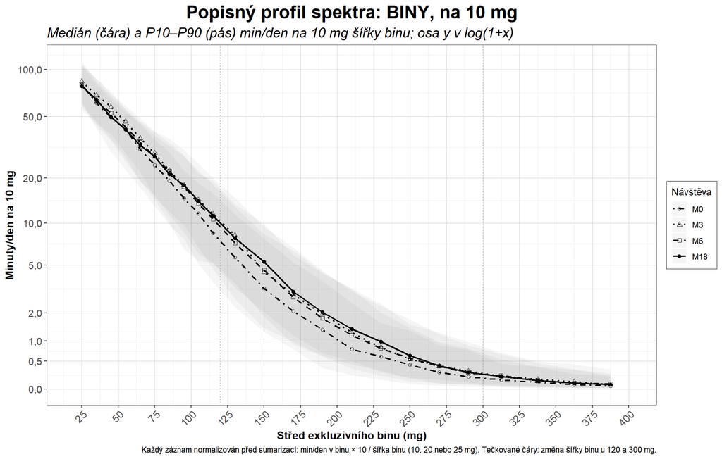

**Co ukazuje (revize, A07-A).**

- Denní profil intenzity **na 10 mg šířky binu**: medián minut za den na 10 mg v každém exkluzivním binu (čára) a rozsah 10.–90. percentilu (pás), zvlášť pro každou návštěvu.
- Každý záznam se před sumarizací normalizuje (minuty v binu × 10 / šířka binu). Nativní biny GGIR mají šířku 10 mg do 120 mg, 20 mg do 300 mg a 25 mg do 400 mg (tečkované čáry).
- Osa y je stlačená (log 1 + x), aby několik minut ve vysoké intenzitě zůstalo vidět vedle hodin v nízké intenzitě.

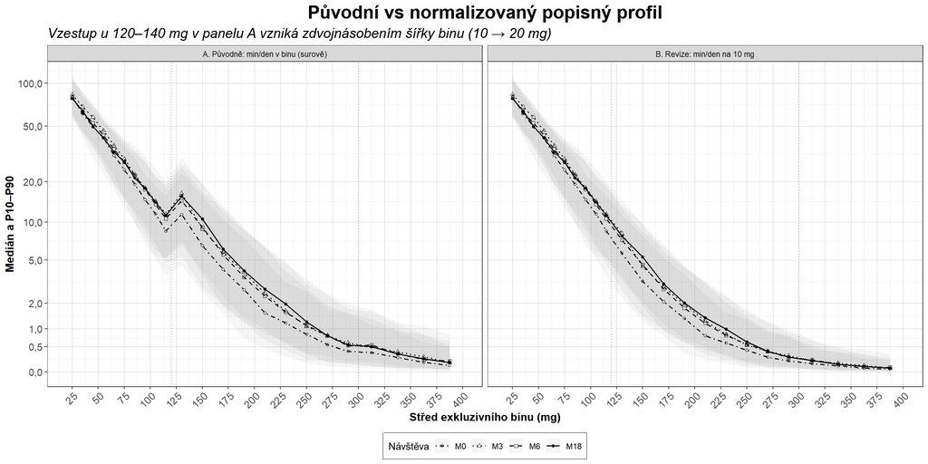

**Hodnocení.**

- Původní figura (panel A, beze změny z prvního reportu) zobrazovala minuty *v binech* nestejné šířky. Její lokální vzestup u 120–140 mg vzniká výhradně zdvojnásobením šířky binu z 10 na 20 mg. Surový medián u 120–140 mg stoupá při každé návštěvě (ověřeno).
- Po normalizaci (panel B) medián **s intenzitou monotónně klesá při každé návštěvě** (mezi žádnými sousedními biny nestoupá). Lokální vrchol neexistuje.
- Změnu tvaru plně vysvětluje normalizační faktor. Normalizované kvantily se v každém binu a návštěvě rovnají surovým kvantilům × 10 / šířka a surové hodnoty přesně reprodukují původní tabulku (validace R2, R9b).
- Čas s intenzitou strmě klesá: většina dne připadá na hodnoty pod 100 mg a nad ~250 mg typický pacient nasbírá výrazně méně než minutu denně na 10 mg.
- Křivky kontrol (M3, M6, M18) leží zhruba od 70 mg výše mírně, ale soustavně nad výchozí křivkou (M0, čerchovaná). To předjímá hlavní výsledek: široký posun nahoru místo jediného vrcholu.

**Pozor:** Chybějící návštěvy nechybí zcela náhodně.

- Pacienti, kterým později chybí M18, měli spíše větší zisky v M3 (S10).
- E1/E2 proto používají MMRM, který je platný při MAR. Odhad pro M18 je navíc zátěžově testován analýzou tipping point s delta-adjustací (S9).
- Důvody chybění M0/M18 v master datasetu zaznamenány nejsou.

# 5 Statistické metody, alternativní modely a nezávislá oponentura

## Modely

**E1 a E2.** Pro každý exkluzivní bin a zvlášť pro každý kumulativní práh se minuty/den modelují smíšeným modelem pro opakovaná měření:

- návštěva (M0, M3, M6, M18) je pevný faktor s nestrukturovanou kovariancí na úrovni pacienta (glmmTMB, REML);
- výsledek se kvůli numerické stabilitě škáluje svou SD a zpětně transformuje.

E1 je kontrast návštěv v min/den na 10 mg šířky binu. E2 je poměr modelových marginálních průměrů (β₀ + βₓ)/β₀. Pokud nestrukturovaný model nekonverguje, použije se model s náhodným interceptem; tyto náhrady se zaznamenávají.

**E3.** Každý záznam je reprezentován jako 21dílná 24h kompozice: <20 mg, 19 binů od 20 do 300 mg a ≥300 mg. Nuly se nahrazují multiplikativně hodnotou 0,65 × jedna 5s epocha na záznam. Analýza pak probíhá ve třech krocích:

1. Pro každou část se spočítají průměrné párové změny centrovaných log-poměrů (clr).
2. Pro ohraničené biny se tyto změny regresují na log geometrického středu intenzity přirozeným splinem (df = 3), který slouží jako hladký null.
3. Rezidua jsou estimandem odchylky tvaru.

**Nejistota.** Všechny intervaly poskytuje pacientský cluster bootstrap:

- jedna sada výběrů pacientů je společná všem estimandům, binům, prahům i návštěvám;
- duplikovaní pacienti dostávají nová ID clusteru a výběry jsou generované předem, takže výsledky nezávisí na počtu workerů.

Report z bootstrapu ukazuje bodové percentilové intervaly a simultánní 95% pásy (max-t přes biny jedné návštěvy). Z pásů jsou odvozeny vnitřní a vnější konfidenční množiny.

## Rozhodovací pravidlo

**Lokalizovaný informativní interval** se reportuje, jen když platí obojí:

- rezidua E3 ukazují *hrb*: alespoň 2 sousední biny, jejichž simultánní pás vylučuje nulu, z obou stran ohraničené biny, u kterých to neplatí, a nedotýkající se okraje mřížky;
- hrb je invariantní vůči hodnotě náhrady nul (epocha, 0,01, 0,5 min/den), omezení na ≥ 5 validních dnů a vyřazení pacienta s UCTD/SSc.

Jinak report uvádí, že **neexistuje doklad lokální odchylky**. Doplní buď, že změna je hladkou redistribucí k vyšším intenzitám (když je lineární sklon nenulový), nebo že změnu tvaru nelze identifikovat.

Pokrytí a velikost změny se reportují jako samostatné deskriptivní dimenze, ne jako brány.

## Nezávislá oponentura

Plán oponoval jiný model (Claude Fable 5.1). Proběhla dvě kola, obě s verdiktem REVISE, a každá námitka byla vypořádána:

- úplná oponentura: `docs/261013_phase3_independent_review.md`;
- vypořádání bod po bodu a uzamčený plán v2: `docs/261013_phase3_disposition_and_locked_plan.md`.

Hlavní změny:

- tvrzení, že odpověď ve vysokých intenzitách je artefakt SD, bylo staženo;
- E1 bylo normalizováno na 10 mg;
- E2 bylo převedeno na MAR;
- byl zaveden estimand tvaru E3 s hladkým nullem;
- branové rozhodovací pravidlo nahradily konfidenční množiny;
- posuvná okna byla vypuštěna.

## Revize A07

*Nezávislá oponentura revize:* Claude Fable 5.1, verdikt MINOR REVISION (žádné kritické nálezy; tři hlavní nálezy k interpretaci, všechny vypořádány). Viz `docs/261016_A07_independent_review.md` a vypořádání v `docs/261016_A07_validation_change_log_summary.md` §5.

Revize vychází z `MYO_A07_narhy_na_zmeny.txt`. Úplné posouzení bod po bodu (přijato / upraveno / zamítnuto, se zdůvodněním) je v `docs/261016_A07_critical_review.md`. Původní skripty 01–06 i původní report jsou beze změny; revize přidává skripty 07–10.

**A — Popisný profil na 10 mg.** Minuty každého záznamu v binu se násobí 10 / šířka binu (10, 20 nebo 25 mg) *před* výpočtem mediánu a P10–P90. Protože je šířka v rámci binu konstantní, je to numericky totožné s přeškálováním souhrnů; žádné syntetické 10mg biny se neinterpolují.

**B — Koncentrace změny.** V každém binu a návštěvě (kompletní páry) jsou „top 10 %“ k = ceiling(0,1 × n) pacientů s největší změnou, kde n zahrnuje *všechny* páry buňky. Reportují se tři různé veličiny:

- **% pacientů se ziskem** (změna > 0);
- **koncentrace kladných zisků** (nová): součet k největších *kladných* zisků dělený součtem všech kladných zisků. Při stejných ziscích by měla hodnotu min(k, n₊)/n₊, což je zároveň její minimum;
- **podíl na čistém zisku** (původní): součet k největších změn dělený součtem všech změn. Při čisté změně ≤ 0 je nedefinovaný a při téměř vyrušených ziscích a ztrátách nestabilní, proto se uvádí spolu s *indexem net/gross* Σ změna / Σ |změna|. Buňky s indexem pod 0,20 jsou označené jako nestabilní.

Shody na k-té hodnotě součty nemění. Intervaly pocházejí ze stejného pacientského cluster bootstrapu jako primární analýza (B = 2000, seed 20261013).

**C — Robustnost testu tvaru (E3).** Párová změna clr minus hladký trend je algebraicky invariantní vůči normalizaci na 10 mg i vůči centru clr. Obojí přidává konstanty, které pohltí intercept splinu, což je ověřeno i numericky. Šířka binu se proto do E3 promítá jen polohou binů na ose log-intenzity a jejich rozlišením. Testované varianty:

- hladký null s df = 1 (přímka), 2, 4 a 5;
- fit vážený log-šířkou binu;
- jednotná mřížka 20 mg (změna rozlišení);
- ohraničené biny až do 400 mg (změna rozsahu kompozice).

Simulace plasmode srovnává míru falešných poplachů a sílu pro df = 2–5, včetně misspecifikovaného nullu, kde má skutečný hladký profil df = 5.

**D — Liší se tvar změny mezi kontrolami?** U pacientů s M0 a oběma návštěvami se párový rozdíl profilů změny clr hodnotí třemi způsoby: bin po binu s max-t pásem, jako rozdíl lineárního sklonu a 3-df bootstrapovým Waldovým testem, že hladká křivka rozdílu je plochá. P-hodnoty jsou Holm-korigované přes tři páry návštěv. Citlivostní analýza používá společný vzorek pacientů se všemi čtyřmi návštěvami.

**E — Podtypy s výchozí závažností (exploratorně).** Výchozí klinické proměnné pocházejí z `klinicka_data_12102026.xlsx`, který je mimo master dataset. Pro tři předem dané souhrny (ΔT100, sklon clr na úrovni pacienta, ΔIG) se fitují modely změny od M0 s náhodným interceptem, s `návštěva × podtyp` (reference DM) a centrovanou výchozí závažností. Závažnost je ph_VAS na 10 mm (hlavní, podle rozhodnutí týmu) nebo MMT8 na 5 bodů (citlivost). Další varianty přidávají závažnost × návštěva nebo výchozí hodnotu výsledku. Kontrasty mají IS z pacientského cluster bootstrapu (B = 2000); testy věrohodnostním poměrem používají fity ML.

# 6 Výsledky — KUMULATIVNÍ prahy

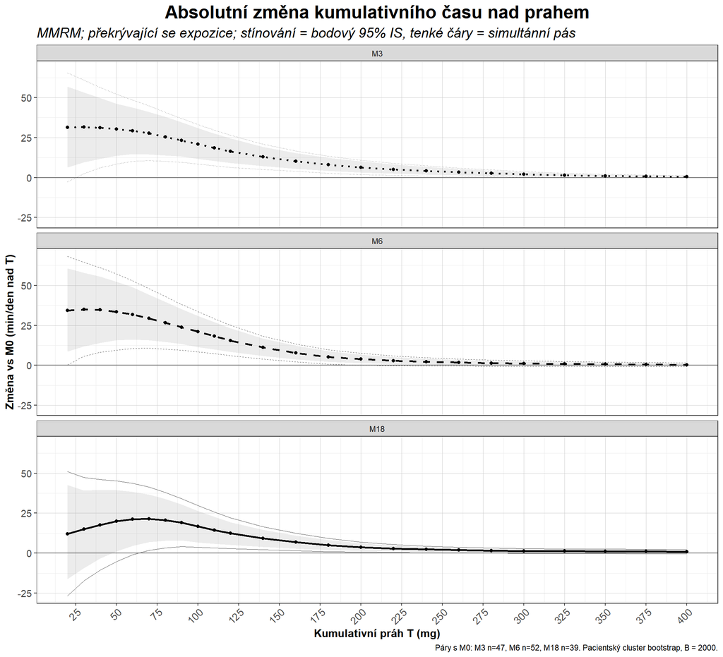

**Co ukazuje.**

- O kolik minut denně víc tráví pacienti při kontrole *nad* každým prahem T ve srovnání s M0, s 95% IS (stínování) a simultánním pásem (tenké čáry).
- „Nad 100 mg“ odpovídá konvenčnímu prahu GGIR „MVPA“. Toto označení není u myozitid validovanou kategorií střední intenzity.

**Hodnocení.**

- Zisk je největší u nízkých prahů: nad 40 mg 31,2 (95% IS 11,8 až 49,9) min/den v M3. S prahem plynule klesá, protože každý vyšší práh obsahuje méně času.
- Nad 100 mg je zisk 20,9 a 21,0 min/den v M3 a M6 a 16,8 min/den v M18.
- Nad 200 mg je to v M3 stále 6,5 (95% IS 3,2 až 10,1) min/den.

**Proč je to zajímavé.**

- Zisk nad 100 mg znamená zhruba o třetinu více takového času než na začátku (výchozí medián 51 min/den).
- Trvá i v M18, za předpokladu MAR (viz analýza tipping point).
- Zda je změna této velikosti u IIM klinicky významná, stanoveno není. K tomu by bylo nutné ukotvení k funkci (např. MMT8, FI2, HAQ), což je mimo rozsah tohoto reportu.

**Pozor:** Prahy se překrývají: T100 obsahuje vše nad 100 mg včetně času nad 200 mg. Křivka proto neumí říct, *kde* ke změně dochází; na to odpovídají exkluzivní biny níže.

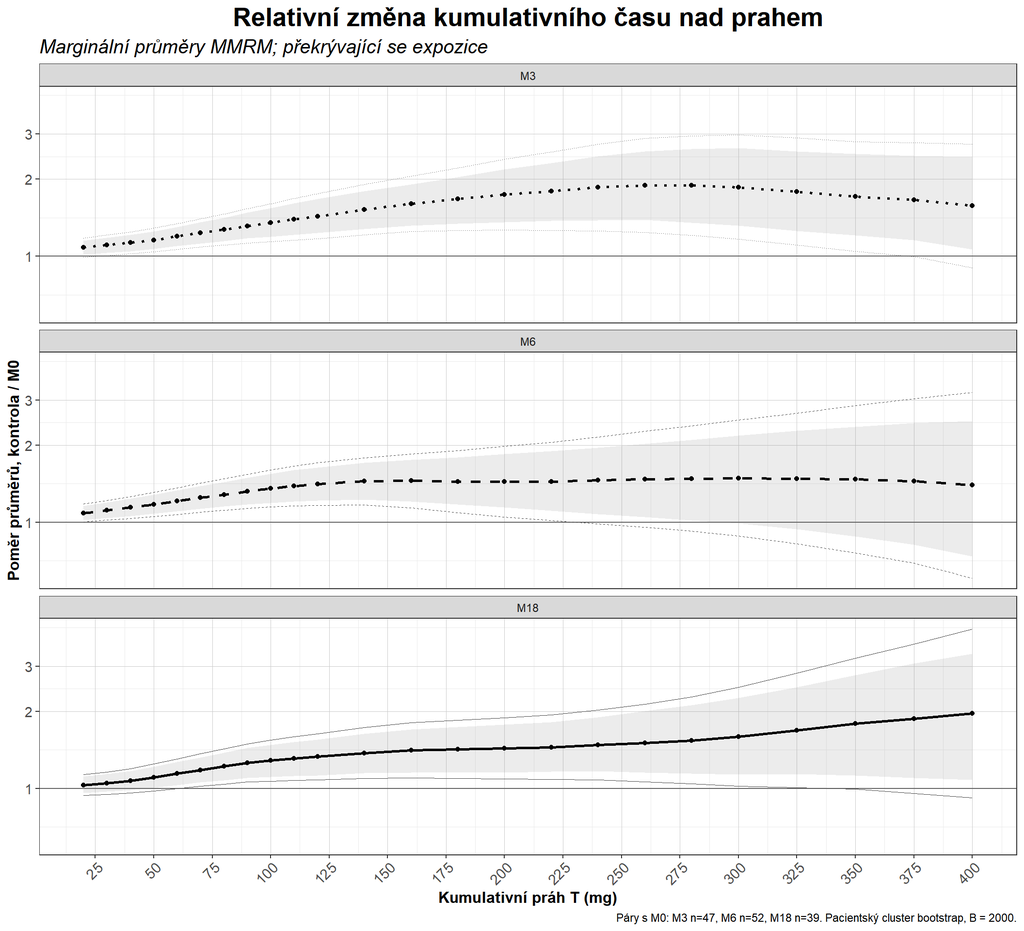

**Co ukazuje.** Totéž srovnání na *relativní* škále: čas nad T při kontrole dělený časem nad T v M0 (1 = beze změny). Osa y je logaritmická.

**Hodnocení.**

- Nad 20 mg je relativní změna malá (+8 % v M3), protože nad 20 mg je téměř celý bdělý den.
- Relativní zisk v M3 s prahem roste:
  - +35 % nad 100 mg;
  - +74 % nad 200 mg;
  - +86 % nad 300 mg.
- Čím intenzivnější pohyb, tím větší *proporcionální* nárůst, i když jde o malý počet minut.

**Poznámka:** Kumulativní prahy jsou doplňkovou reprezentací a k lokalizaci se nepoužívají.

# 7 Výsledky — exkluzivní BINY

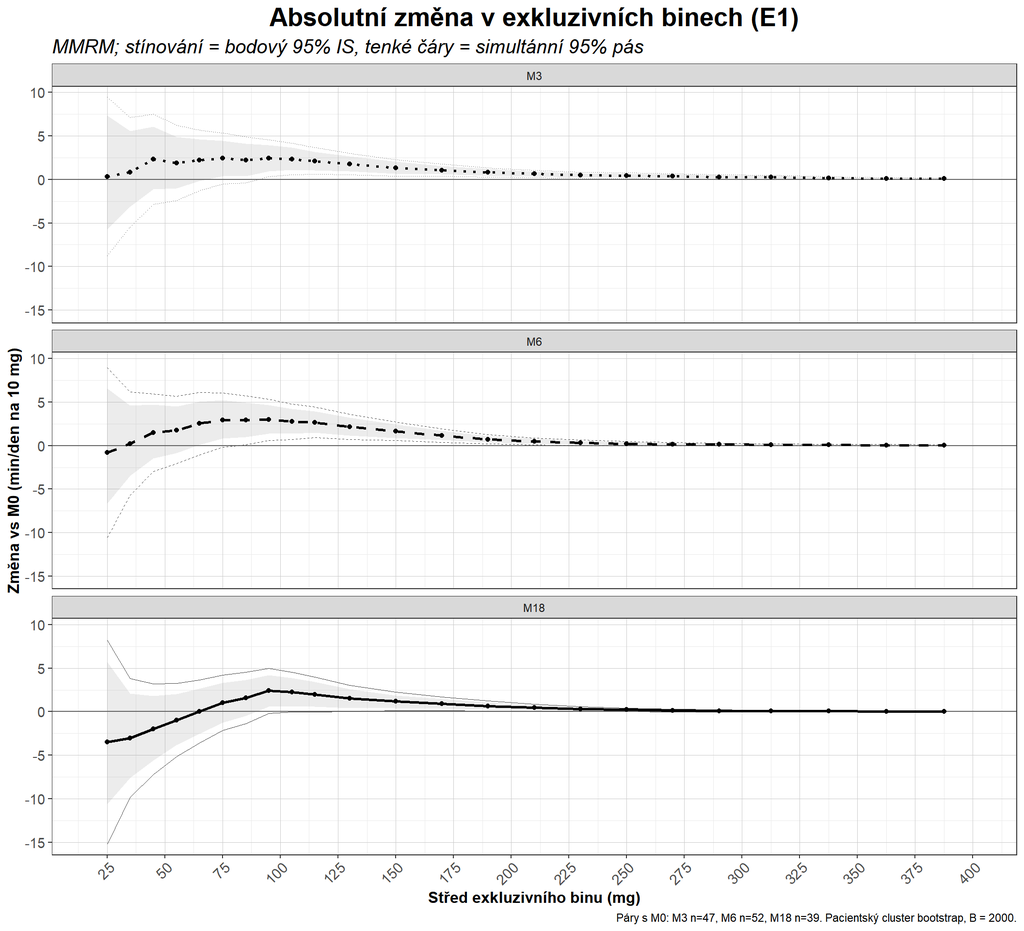

**Co ukazuje.**

- Absolutní změnu minut za den strávených *v* každém nepřekrývajícím se binu intenzity, na 10 mg šířky binu.
- Biny mají šířku 10, 20 nebo 25 mg; hodnoty na 10 mg je činí srovnatelnými.
- **Jak číst:** odhad 2,5 v 90–100 mg znamená, že pacienti v tomto 10mg úseku intenzity tráví v průměru o 2,5 minuty denně více než na začátku.

**Hodnocení.**

- V M3 a M6 jsou bodové odhady absolutního zisku zhruba 1,5–3 min/den na 10 mg od ~40 mg do ~120 mg a k 200 mg slábnou.
  - 90–100 mg: 2,4 (95% IS 1,0 až 3,9) v M3 a 3,0 (95% IS 1,3 až 4,7) v M6.
- Simultánní pás vylučuje nulu až zhruba od 80–90 mg: 90–300; 325–400 mg v M3 a 80–240 mg v M6.
- Pod touto hranicí nelze podobně velké zisky odlišit od nuly. Čas v nízké intenzitě kolísá mezi pacienty i u pacienta mnohem víc: bootstrapová SE je zhruba 1,3–1,9 v 40–70 mg oproti zhruba 0,8 v 90–100 mg.
- Dolní hranice „jistého“ rozsahu tak odráží stejně přesnost jako velikost změny.
- V M18 jsou bodové odhady v nejnižších binech (20–50 mg) záporné, jejich IS ale obsahují nulu, takže se tam nedá nic uzavřít.

**Pozor:** Rozsah 20–50 mg obsahuje v analýze 0–24 h i neklidný spánek a velmi lehký pohyb. Změny v něm nelze vykládat jako změnu určitého typu denní aktivity.

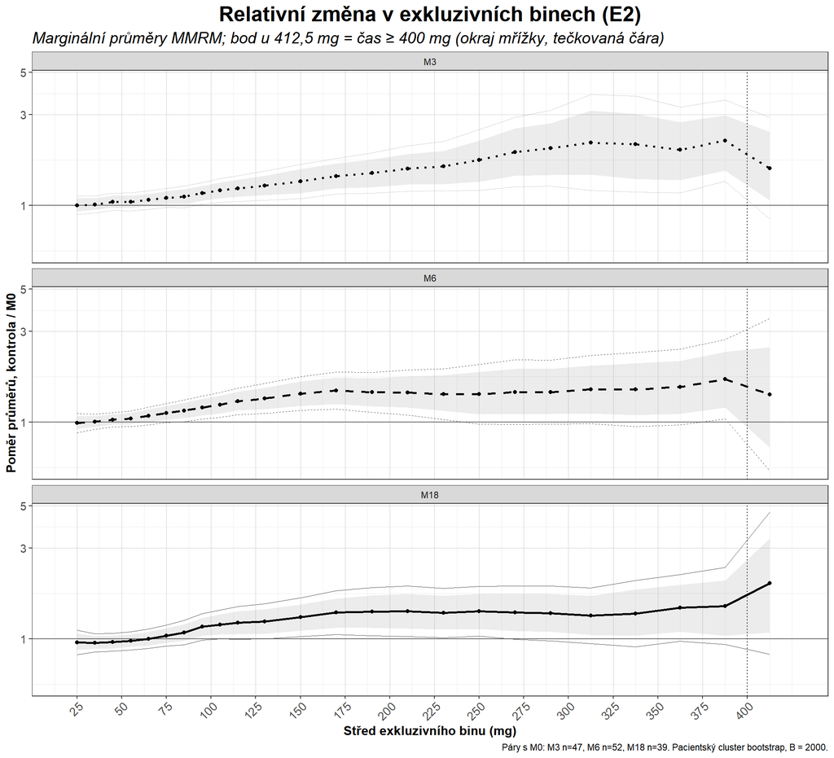

**Co ukazuje.**

- Relativní změnu v každém binu: poměr průměrných minut při kontrole a v M0 ze stejného modelu (1 = beze změny).
- Poslední bod (≥ 400 mg) je čas nad horním okrajem měřené mřížky; tečkovaná čára proto označuje konec měřicí škály.

**Hodnocení.**

- Pod ~60 mg relativní změna není (poměr ≈ 1).
- Od ~70 mg poměr s intenzitou roste. V M3:
  - ×1,20 v 100–110 mg;
  - ×1,56 v 200–220 mg;
  - ×2,14 v 300–325 mg.
- V M6 a M18 jsou poměry ve vysokých intenzitách menší, zhruba ×1,3–1,7.
- Simultánní pás vylučuje 1 v rozsahu 80–240; 375–400 mg v M6 a jen v rozsahu 140–260 mg v M18.
- Neexistuje vrchol s následným poklesem, který by vymezoval „optimální pásmo“. Křivka roste a pak se ustálí.

**Proč je to zajímavé.**

- Čas v binech nejvyšší intenzity se při časné kontrole zhruba *zdvojnásobí*, ovšem z velmi nízkého východiska několika minut týdně na bin.
- Může to odrážet obnovenou schopnost krátkých, náročnějších úseků pohybu. ENMO na zápěstí nebylo u IIM validováno proti typu aktivity, druh aktivity proto nelze pojmenovat.
- Horní hranici tohoto efektu nelze určit, protože mřížka GGIR končí na 400 mg.

E1 (min/den na 10 mg) a E2 (poměr průměrů) pro jednotlivé exkluzivní biny

| Bin | Estimand | Návštěva | Odhad | 95% IS | Simult. pás |
| --- | --- | --- | --- | --- | --- |
| 100-110 | E1 | M3 | 2,36 | 1,12 až 3,64 | 0,55 až 4,17 |
| 100-110 | E1 | M6 | 2,75 | 1,36 až 4,24 | 0,72 až 4,79 |
| 100-110 | E1 | M18 | 2,25 | 0,63 až 3,85 | -0,02 až 4,53 |
| 110-120 | E1 | M3 | 2,11 | 1,07 až 3,17 | 0,58 až 3,64 |
| 110-120 | E1 | M6 | 2,66 | 1,48 až 3,96 | 0,91 až 4,41 |
| 110-120 | E1 | M18 | 1,98 | 0,57 až 3,41 | -0,01 až 3,98 |
| 120-140 | E1 | M3 | 1,77 | 0,91 až 2,66 | 0,54 až 3,00 |
| 120-140 | E1 | M6 | 2,16 | 1,17 až 3,21 | 0,73 až 3,59 |
| 120-140 | E1 | M18 | 1,53 | 0,44 až 2,57 | 0,01 až 3,05 |
| 140-160 | E1 | M3 | 1,34 | 0,69 až 2,06 | 0,40 až 2,29 |
| 140-160 | E1 | M6 | 1,64 | 0,90 až 2,43 | 0,58 až 2,71 |
| 140-160 | E1 | M18 | 1,19 | 0,43 až 1,89 | 0,14 až 2,24 |
| 160-180 | E1 | M3 | 1,07 | 0,59 až 1,57 | 0,38 až 1,75 |
| 160-180 | E1 | M6 | 1,16 | 0,63 až 1,71 | 0,39 až 1,93 |
| 160-180 | E1 | M18 | 0,93 | 0,38 až 1,47 | 0,15 až 1,72 |
| 180-200 | E1 | M3 | 0,80 | 0,43 až 1,20 | 0,26 až 1,34 |
| 180-200 | E1 | M6 | 0,73 | 0,36 až 1,12 | 0,19 až 1,26 |
| 180-200 | E1 | M18 | 0,65 | 0,25 až 1,07 | 0,07 až 1,24 |
| 20-30 | E1 | M3 | 0,35 | -5,75 až 7,35 | -8,78 až 9,47 |
| 20-30 | E1 | M6 | -0,82 | -6,62 až 6,54 | -10,58 až 8,94 |
| 20-30 | E1 | M18 | -3,51 | -10,63 až 5,73 | -15,24 až 8,22 |
| 200-220 | E1 | M3 | 0,63 | 0,34 až 0,95 | 0,20 až 1,07 |
| 200-220 | E1 | M6 | 0,49 | 0,23 až 0,79 | 0,08 až 0,89 |
| 200-220 | E1 | M18 | 0,45 | 0,16 až 0,74 | 0,03 až 0,86 |
| 220-240 | E1 | M3 | 0,48 | 0,24 až 0,74 | 0,13 až 0,84 |
| 220-240 | E1 | M6 | 0,32 | 0,12 až 0,57 | 0,00 až 0,64 |
| 220-240 | E1 | M18 | 0,29 | 0,10 až 0,51 | 0,01 až 0,58 |
| 240-260 | E1 | M3 | 0,42 | 0,19 až 0,67 | 0,08 až 0,76 |
| 240-260 | E1 | M6 | 0,23 | 0,06 až 0,44 | -0,04 až 0,50 |
| 240-260 | E1 | M18 | 0,23 | 0,08 až 0,38 | 0,01 až 0,44 |

[output cut: 111 more lines]

**Jak číst.**

- Řádky E1 udávají minuty/den na 10 mg, řádky E2 poměr průměrů.
- „Simult. pás“ je konzervativní interval, který udržuje 95% pokrytí současně přes všechny biny návštěvy. Používejte ho pro tvrzení o tom, *které* biny se změnily.

# 8 Informativnost celého spektra

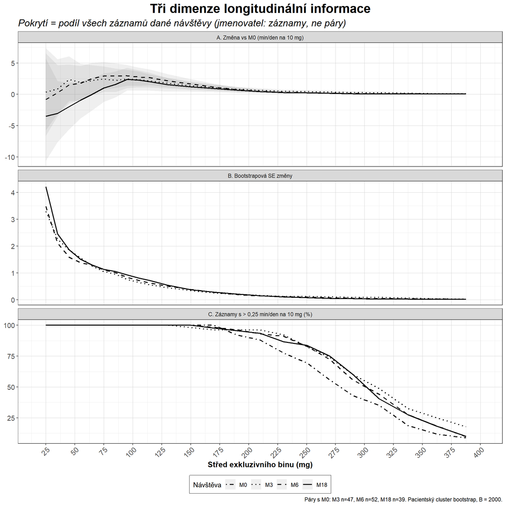

**Co ukazuje.** Tři vlastnosti každého binu vedle sebe:

- **A:** jak velká je změna;
- **B:** jak přesně je odhadnuta (bootstrapová směrodatná chyba; menší = přesnější);
- **C:** kolik procent záznamů obsahuje v daném binu alespoň minimální čas (> 0,25 min/den na 10 mg).

Panel C obsahuje jako referenci i M0.

**Hodnocení.**

**Proč je to zajímavé.**

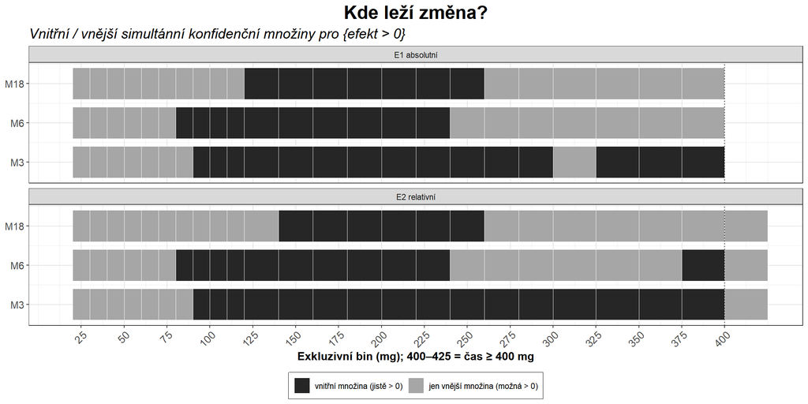

**Jak číst.**

- **Černé** biny jsou ty, kde je změna kladná *se simultánní 95% jistotou*.
- **Šedé** biny jsou ty, kde je kladná změna možná, ale neprokázaná.
- **Bílé** by byly biny, kde nemá oporu ani kladná změna.

**Hodnocení.**

- Na absolutní škále je změna jistě kladná v rozsahu 90–300; 325–400 mg v M3, 80–240 mg v M6 a 120–260 mg v M18.
- Požadavek alespoň +0,5 min/den na 10 mg rozsah zužuje na 100–140 mg v M3 a 90–160 mg v M6.
- Tyto rozsahy vymezují, kde je změna *jistě* kladná. Jejich dolní hranice (zhruba 80–90 mg) odráží stejně přesnost jako velikost: pod ní jsou podobně velké zisky odhadnuté příliš nepřesně. Nejde proto o doporučené pásmo.

## Tvar změny (E3)

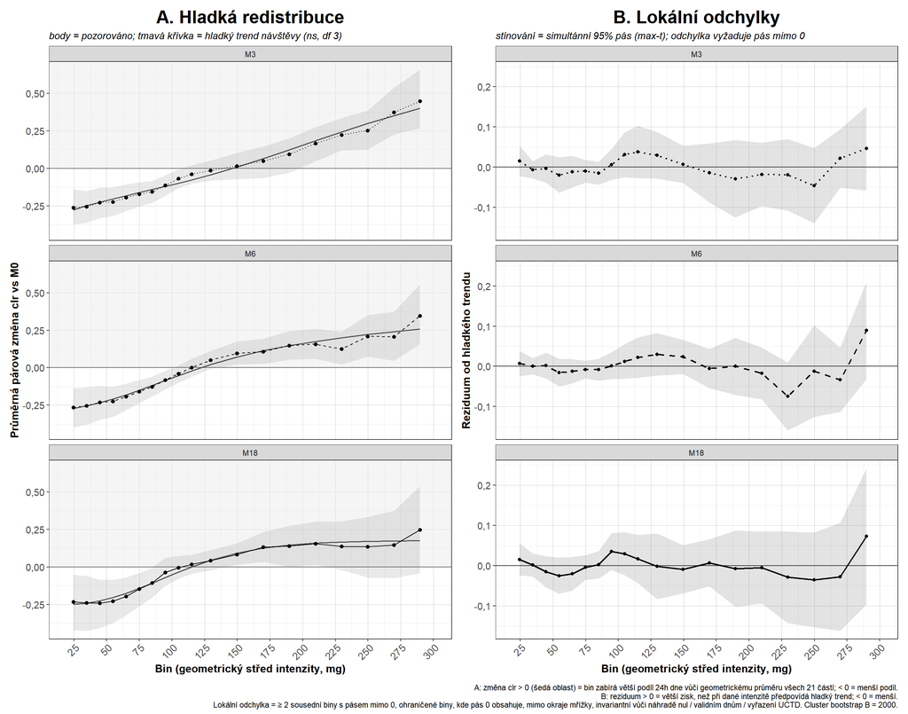

**Co ukazuje (výklad revidován, A07-C; čísla beze změny).**

Každý záznam je chápán jako 24h kompozice 21 částí: <20 mg, 19 binů od 20 do 300 mg a ≥300 mg. Pro každou část je *centrovaný log-poměr* (clr) logaritmus jejích minut minus průměrný logaritmus všech 21 částí, tedy její velikost **vůči geometrickému průměru celého dne**. Figura ukazuje průměrnou *párovou změnu* clr od M0 do každé kontroly.

**Panel A — hladká redistribuce.**

- **Body se stínovaným 95% IS:** pozorovaná průměrná změna clr v každém binu.
- **Tmavá křivka:** hladký trend dané návštěvy, přirozený spline (df 3) v log intenzitě, fitovaný zvlášť pro M3, M6 a M18 se stejnou specifikací.
- **Kladné hodnoty (šedá oblast):** bin zabírá *větší podíl dne* než v M0, ve srovnání s ostatními částmi. **Záporné hodnoty:** menší podíl.
- Protože je clr relativní, záporná hodnota *neznamená* méně absolutních minut. Biny 40–70 mg mají zápornou změnu clr, přestože se jejich absolutní minuty téměř nemění (E1); jen rostou méně než zbytek denní aktivity.

**Panel B — lokální odchylky.**

- **Čára:** reziduum, tedy pozorovaná změna clr minus hladký trend.
- **Kladné reziduum:** bin získal *více*, než hladký trend při jeho intenzitě předpovídá. **Záporné reziduum:** získal méně.
- **Stínovaný pás:** simultánní 95% pás (max-t přes 19 binů návštěvy; pacientský cluster bootstrap, B = 2000). Kontroluje pravděpodobnost *jakéhokoli* falešného překročení v celém spektru, ne bin po binu.
- **Kritéria lokální odchylky** (všechna musí platit): ≥ 2 sousední biny s pásem vylučujícím 0; z obou stran ohraničené biny, jejichž pás 0 obsahuje; mimo okraje mřížky; a stejný výsledek při každé hodnotě náhrady nul, při ≥ 5 validních dnech i po vyřazení pacienta s UCTD/SSc.

**Hodnocení.**

- **Panel A:** při každé návštěvě křivka plynule stoupá od záporných hodnot (nízké intenzity ztrácejí podíl) ke kladným (vysoké intenzity podíl získávají).
  - Podíl dne pod 20 mg klesá (změna clr v M3 -0,27 (95% IS -0,42 až -0,12)).
  - Podíl nad 300 mg roste (0,37 (95% IS 0,17 až 0,59)).
- **Panel B:** rezidua zůstávají všude uvnitř pásu, lokální hrb tedy neexistuje.

**Proč je to zajímavé.**

- To je ústřední výsledek. V rozlišení testu vypadá zlepšení u IIM jako **„naklopení“ celého profilu aktivity**: biny nízké intenzity ztrácejí relativní podíl a biny vysoké intenzity ho získávají.
- Žádný rozsah intenzity nad toto hladké naklopení nevystupuje.
- **Rozlišení testu:** lokální zisky navíc o zhruba +22 % (+0,2 log) v šíři 2–6 binů by byly s velkou pravděpodobností odhaleny. Menší odchylky kolem +10 % mohou uniknout, zejména v M18 (viz tabulka síly ve validační části).
- Klinicky to hovoří pro popis zotavení měřítky celého profilu spolu s měřítkem objemu, nikoli jediným novým prahem.

**Co „žádná lokální odchylka“ *neznamená*.** Nepřítomnost statisticky podloženého hrbu neprokazuje, že by všechny oblasti intenzity byly klinicky stejně informativní. Oblasti se liší tím, kolik minut se mění (E1), relativní změnou (E2), přesností a pokrytím (F4) i tím, jak široce je zisk sdílen (F6). Test tvaru říká jen to, že při tomto rozlišení a velikosti vzorku žádný bin nezískává zřetelně víc nebo méně, než předpovídá hladké naklopení.

### Je verdikt E3 robustní vůči mřížce binů a specifikaci hladkého nullu? (A07-C)

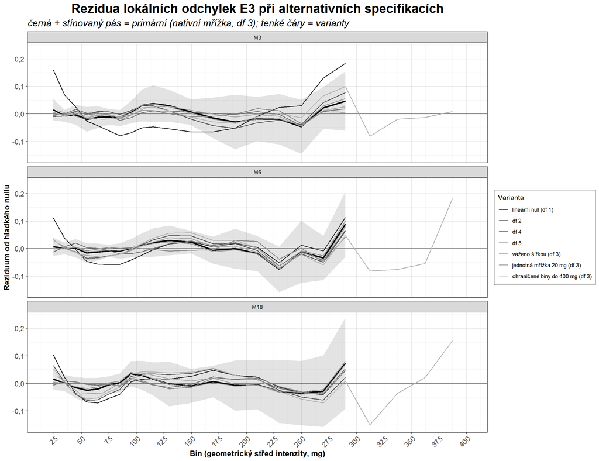

Pravidlo hrbu E3 při alternativních hladkých nullech a mřížkách binů (maticový cluster bootstrap, B = 2000)

| Varianta | Třída | Návštěva | Biny | Kladné hrby | Záporné hrby | Biny s pásem mimo 0 | Verdikt |
| --- | --- | --- | --- | --- | --- | --- | --- |
| primární (nativní, df 3) | primární | M3 | 19 |  |  | 0 | bez lokální odchylky |
| primární (nativní, df 3) | primární | M6 | 19 |  |  | 0 | bez lokální odchylky |
| primární (nativní, df 3) | primární | M18 | 19 |  |  | 0 | bez lokální odchylky |
| lineární null (df 1) | specifikace hladkého nullu | M3 | 19 |  |  | 2 | bez lokální odchylky |
| lineární null (df 1) | specifikace hladkého nullu | M6 | 19 |  | 50-70 mg | 2 | označen hrb |
| lineární null (df 1) | specifikace hladkého nullu | M18 | 19 |  | 50-70 mg | 2 | označen hrb |
| df 2 | specifikace hladkého nullu | M3 | 19 |  |  | 0 | bez lokální odchylky |
| df 2 | specifikace hladkého nullu | M6 | 19 |  |  | 0 | bez lokální odchylky |
| df 2 | specifikace hladkého nullu | M18 | 19 |  | 50-70 mg | 2 | označen hrb |
| df 4 | specifikace hladkého nullu | M3 | 19 |  |  | 0 | bez lokální odchylky |
| df 4 | specifikace hladkého nullu | M6 | 19 |  |  | 0 | bez lokální odchylky |
| df 4 | specifikace hladkého nullu | M18 | 19 |  |  | 0 | bez lokální odchylky |
| df 5 | specifikace hladkého nullu | M3 | 19 |  |  | 0 | bez lokální odchylky |
| df 5 | specifikace hladkého nullu | M6 | 19 |  |  | 0 | bez lokální odchylky |
| df 5 | specifikace hladkého nullu | M18 | 19 |  |  | 0 | bez lokální odchylky |
| váženo šířkou (df 3) | specifikace hladkého nullu | M3 | 19 |  |  | 0 | bez lokální odchylky |
| váženo šířkou (df 3) | specifikace hladkého nullu | M6 | 19 |  |  | 0 | bez lokální odchylky |
| váženo šířkou (df 3) | specifikace hladkého nullu | M18 | 19 |  |  | 0 | bez lokální odchylky |
| jednotná mřížka 20 mg (df 3) | změna rozlišení (mění estimand) | M3 | 14 |  |  | 0 | bez lokální odchylky |
| jednotná mřížka 20 mg (df 3) | změna rozlišení (mění estimand) | M6 | 14 |  |  | 0 | bez lokální odchylky |
| jednotná mřížka 20 mg (df 3) | změna rozlišení (mění estimand) | M18 | 14 |  |  | 0 | bez lokální odchylky |
| ohraničené biny do 400 mg (df 3) | změna rozsahu kompozice (mění estimand) | M3 | 23 |  |  | 0 | bez lokální odchylky |
| ohraničené biny do 400 mg (df 3) | změna rozsahu kompozice (mění estimand) | M6 | 23 |  |  | 0 | bez lokální odchylky |
| ohraničené biny do 400 mg (df 3) | změna rozsahu kompozice (mění estimand) | M18 | 23 |  |  | 0 | bez lokální odchylky |

**Co ukazuje.**

- **Proč šířka binu nemůže E3 přímo zkreslit.** Normalizace na 10 mg násobí každý bin konstantou (10 / šířka) a centrum clr je konstantou na záznam. V *párové změně* se obojí odečte nebo ho pohltí intercept splinu. Rezidua jsou proto totožná, ať se použijí minuty, minuty na 10 mg, nebo hodnoty clr; numerický rozdíl je pod 10⁻¹⁵ (validace R5b).
- **Dvě zbývající cesty, kudy šířka binu působí.** Nestejné šířky ovlivňují (i) kde biny leží na ose log-intenzity, s 10 body v 20–120 mg a 9 v 120–300 mg, a (ii) jak jemně je spektrum rozlišeno.
- **Varianty, které tyto cesty testují:**
  - fit, který každý bin váží rozsahem log-intenzity, jejž pokrývá;
  - jednotná mřížka 20 mg (14 binů);
  - ohraničené biny až do 400 mg (23 binů).

  Poslední dvě mění rozlišení nebo rozsah, a tedy i estimand; jde o kontroly robustnosti *závěru*, ne téhož čísla.
- **Pružnost hladkého nullu:** df = 1 (přímka), 2, 4 a 5 vedle primárního df = 3.

**Hodnocení.**

- S hladkým nullem df ≥ 3, s vážením šířkou i na obou alternativních mřížkách **není při žádné návštěvě označena lokální odchylka** (ověřeno).
- Něco označí jen dva nejméně pružné nully: *zápornou* oblast v 50–70 mg. Přímka (df 1) ji označí v M6 a M18, df 2 jen v M18.
  - Jde o zakřivení esovitého profilu z panelu A, které přímka ani spline s df 2 nedokážou sledovat; tento problém byl identifikován už v původním plánu (R1).
  - Simulace níže ukazuje, že df 2 v právě této situaci zvyšuje falešné poplachy, zejména v M18. Tato označení proto nejsou dokladem lokálního efektu.

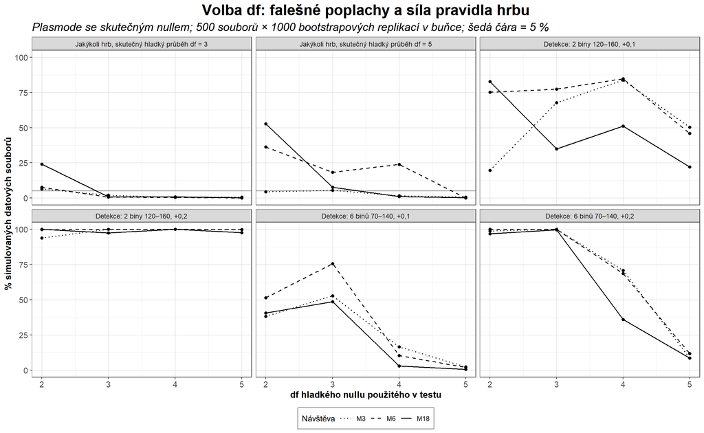

**Co ukazuje.** Simulace plasmode postavená z vlastních párových změn clr pacientů (500 souborů × 1000 bootstrapových replikací v buňce) odpovídá na tři otázky:

- **Falešné poplachy (vlevo nahoře).** Skutečný populační profil je hladký fit df 3 bez hrbu. Jak často pravidlo něco označí, když test používá df 2–5?
- **Misspecifikace (uprostřed nahoře).** Totéž, ale skutečný profil je pružnější fit df 5.
- **Síla (ostatní panely).** Jak často je hrb +10 % nebo +22 % (+0,1 / +0,2 log) vložený do 2 binů (120–160 mg) nebo 6 binů (70–140 mg) detekován na správném místě?

**Hodnocení — je df = 3 rozumná volba?**

- **Kalibrace.** S df 3 drží pravidlo falešné poplachy hluboko pod 5 %, je-li skutečnost hladká (M3 2,0 %; M6 0,6 %; M18 0,8 %). S df 2 stoupají falešné poplachy na M3 6,4 %; M6 7,6 %; M18 24,0 %.
- **Síla.** df 3 odhalí velké hrby (+22 %) téměř vždy, úzké i široké. S df 4–5 začíná spline široké hrby sám pohlcovat: detekce 6binového hrbu +22 % klesá zhruba ze 100 % (df 3) na 9–12 % (df 5).
- **df 4 je věrohodná alternativa.** Pod nullem df 3 je stejně dobře kalibrovaná (≤ 1 % falešných poplachů) a *úzké* malé hrby odhalí častěji než df 3 (2 biny, +10 %: M3 84 %; M6 85 %; M18 51 % vs M3 68 %; M6 77 %; M18 35 %), široké hrby ale ztrácí.
- **Simulace df 3 zčásti zvýhodňuje už svou konstrukcí**, protože jejím „skutečným nullem“ je fit df 3. Kdyby byl skutečný hladký profil tak zvlněný jako fit df 5, nebyla by v M6 kalibrovaná ani df 3, ani df 4 (falešné poplachy M6 18 % u df 3 a M6 24 % u df 4). Takové falešné poplachy by vytvářely hrby a žádný pozorován nebyl, takže to působí proti pozorovanému závěru, ne v jeho prospěch.
- **Závěr.** df = 3 zůstává jako předem zvolená volba uzamčeného plánu s rozumnou rovnováhou kalibrace a síly pro úzké i široké hrby; optimalita prokázána není. Věcný výsledek na ní nezávisí: **df 3, 4 i 5 shodně dávají „bez lokální odchylky“** a zakřivení v 50–70 mg označí jen zjevně příliš rigidní nully df 1–2.

Rozhodnutí E3 při primární specifikaci a všech variantách invariance

| Varianta | Návštěva | Kladné hrby | Záporné hrby | Lineární sklon (95% IS) | Verdikt |
| --- | --- | --- | --- | --- | --- |
| primární (epocha) | M3 |  |  | 0,28 (0,17 až 0,39) | žádný doklad lokální odchylky; hladká redistribuce k vyšším intenzitám |
| primární (epocha) | M6 |  |  | 0,25 (0,13 až 0,37) | žádný doklad lokální odchylky; hladká redistribuce k vyšším intenzitám |
| primární (epocha) | M18 |  |  | 0,22 (0,04 až 0,40) | žádný doklad lokální odchylky; hladká redistribuce k vyšším intenzitám |
| nuly 0,01 min/den | M3 |  |  | 0,27 (0,16 až 0,39) | žádný doklad lokální odchylky; hladká redistribuce k vyšším intenzitám |
| nuly 0,01 min/den | M6 |  |  | 0,25 (0,13 až 0,37) | žádný doklad lokální odchylky; hladká redistribuce k vyšším intenzitám |
| nuly 0,01 min/den | M18 |  |  | 0,22 (0,04 až 0,40) | žádný doklad lokální odchylky; hladká redistribuce k vyšším intenzitám |
| nuly 0,5 min/den | M3 |  |  | 0,30 (0,20 až 0,40) | žádný doklad lokální odchylky; hladká redistribuce k vyšším intenzitám |
| nuly 0,5 min/den | M6 |  |  | 0,23 (0,12 až 0,35) | žádný doklad lokální odchylky; hladká redistribuce k vyšším intenzitám |
| nuly 0,5 min/den | M18 |  |  | 0,21 (0,05 až 0,37) | žádný doklad lokální odchylky; hladká redistribuce k vyšším intenzitám |
| S7 ≥ 5 validních dnů | M3 |  |  | 0,32 (0,22 až 0,43) | žádný doklad lokální odchylky; hladká redistribuce k vyšším intenzitám |
| S7 ≥ 5 validních dnů | M6 |  |  | 0,25 (0,13 až 0,38) | žádný doklad lokální odchylky; hladká redistribuce k vyšším intenzitám |
| S7 ≥ 5 validních dnů | M18 |  |  | 0,21 (0,01 až 0,40) | žádný doklad lokální odchylky; hladká redistribuce k vyšším intenzitám |
| S8 bez UCTD/SSc | M3 |  |  | 0,28 (0,17 až 0,39) | žádný doklad lokální odchylky; hladká redistribuce k vyšším intenzitám |
| S8 bez UCTD/SSc | M6 |  |  | 0,25 (0,13 až 0,37) | žádný doklad lokální odchylky; hladká redistribuce k vyšším intenzitám |
| S8 bez UCTD/SSc | M18 |  |  | 0,22 (0,04 až 0,40) | žádný doklad lokální odchylky; hladká redistribuce k vyšším intenzitám |

**Hodnocení.**

- Verdikt „bez lokální odchylky; hladká redistribuce“ je shodný ve všech variantách:
  - tři způsoby zacházení s nulovými minutami;
  - omezení na ≥ 5 validních dnů;
  - vyřazení pacienta s UCTD/SSc.
- *Lineární sklon* (jak silně se profil naklápí k vyšším intenzitám) je kladný při každé návštěvě:
  - největší v M3: 0,28 (95% IS 0,17 až 0,39);
  - menší v M6 (0,25 (95% IS 0,13 až 0,37)) a v M18 (0,22 (95% IS 0,04 až 0,40)).

## Heterogenita a časování (C1, C3, C5)

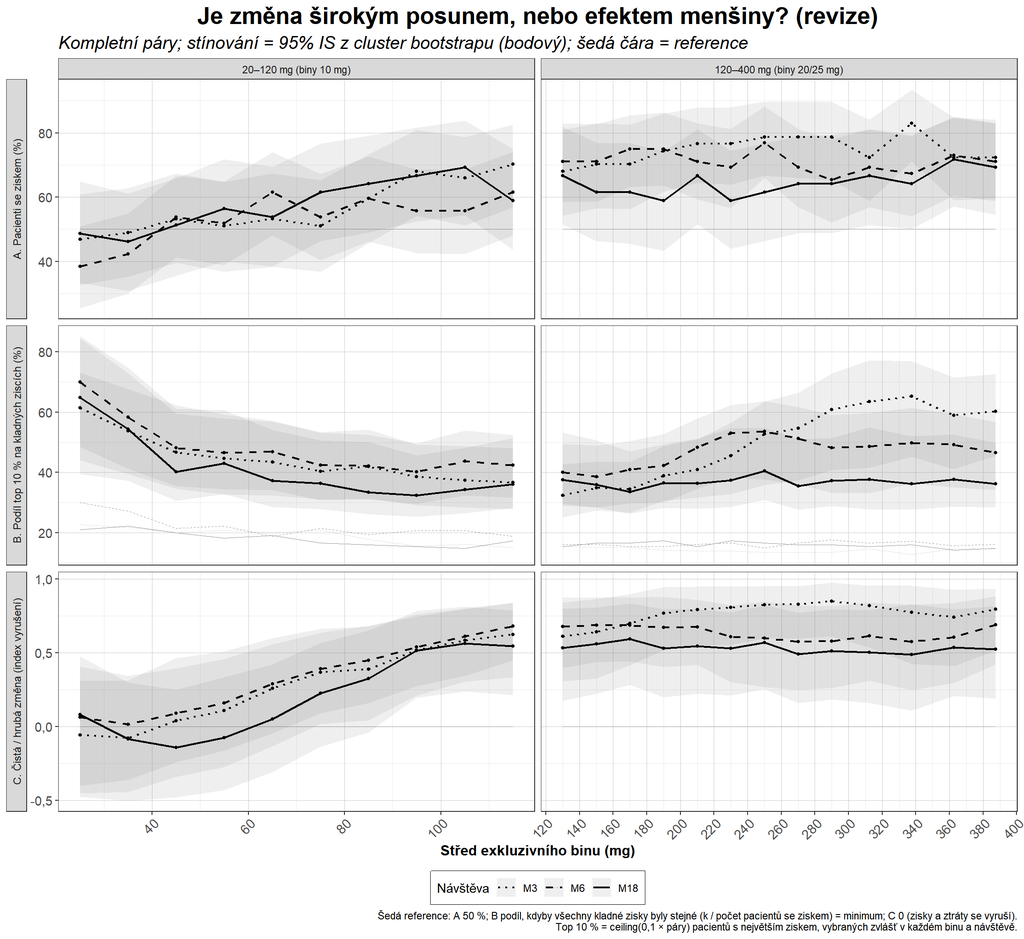

**Co ukazuje (revize, A07-B).** Tři různé otázky držené odděleně; nízké (20–120 mg, vlevo) a vysoké intenzity (120–400 mg, vpravo) mají vlastní osy:

- **A. Pacienti se ziskem:** procento pacientů, jejichž čas v binu vzrostl. 50 % (šedě) by dalo náhodné kolísání nahoru a dolů.
- **B. Koncentrace kladných zisků:** podíl všech kladných zisků, který připadá na 10 % pacientů s největšími zisky (k = ceiling(0,1 × páry): 5 v M3, 6 v M6, 4 v M18). Šedá čára je podíl, kdyby každý pacient se ziskem získal přesně stejně (zhruba 13–30 %). Jde o **nejmenší možnou hodnotu**, ne o realistický null: reálná data leží vždy nad ní. Informativní je, *o kolik* nad ní leží a jak se to liší mezi intenzitami a návštěvami.
- **C. Index net/gross:** součet všech změn dělený součtem jejich absolutních hodnot. Hodnoty blízko 0 znamenají, že se zisky a ztráty vyruší; 1 znamená, že se všichni mění stejným směrem.

Top 10 % se vybírá zvlášť v každém binu a návštěvě; stínování = bodový 95% IS z cluster bootstrapu.

**Hodnocení.**

- **Kolik pacientů získává.** Od 70 mg výše získává čas v binu 51–83 % pacientů podle binu a návštěvy (např. M3, 260–280 mg: 79 (95% IS 66–90) %). Pod ~60 mg je to zhruba polovina, tedy bez konzistentního směru.
- **Jak koncentrované jsou zisky.** Od 60 mg výše připadá na top 10 % 32–65 % kladných zisků, tj. 2,0–5,1násobek nejmenší možné hodnoty (stejné zisky).
  - Koncentrace je **podobně velká ve většině spektra** (32–47 % v 60–200 mg napříč návštěvami).
  - V M3 je **nad ~240 mg numericky vyšší** (64 (95% IS 42–77) % v 300–325 mg); v M6 je kolem 240–260 mg podobná jako v M3; v **M18** zůstává kolem 35 % v celém rozsahu 70–400 mg. Rozdíly mezi návštěvami a intenzitami stojí na překrývajících se bodových intervalech a formálně testovány nebyly. Vynechání jediného pacienta posune podíl v binu ≥ 240 mg až o 10,9 procentního bodu (validace R7); tyto hodnoty ve vysokých intenzitách tedy závisejí na jednotlivých pacientech.
  - Nejvyšší podíly jsou v nejnižších binech (20–40 mg: 54–70 %), kde získává jen zhruba polovina pacientů a čistá změna je blízko nuly; tam statistika popisuje šum, ne zlepšení.
  - Koncentrace v *absolutních minutách* zčásti zrcadlí nerovnoměrnost výchozích hodnot: pacienti, kteří už v dané intenzitě tráví více času, v ní mohou přidat více minut.
  - Souhrnně za veškerý čas nad 100 mg připadá na top 10 % 37 (95% IS 28–47) % kladných zisků v M3, 41 (95% IS 31–51) % v M6 a 35 (95% IS 27–48) % v M18.
- **Zisky a ztráty se v nízkých intenzitách vyruší.** Index net/gross je pod ~60 mg blízko 0 (panel C). Proto tam původní „podíl na čistém zisku“ explodoval (viz níže).

**Co se změnilo oproti prvnímu reportu.**

- První report uváděl, že „nad 200 mg přispívá 10 % pacientů s největšími zisky 46–75 % celkového zisku“, a vykládal to jako *menšinu silných responderů* ve vysokých intenzitách. Toto číslo používalo jako jmenovatel čistý zisk. Nad 200 mg je index net/gross 0,49–0,85, takže podíl na čistém zisku je tam jen mírně vyšší než podíl na kladných ziscích; problém čistého estimandu je hlavně v nízkých binech, kde je nedefinovaný nebo přesahuje 100 %.
- S estimandem kladných zisků připadá na top 10 % zhruba 32–65 % kladných zisků, podobně ve středních i vysokých intenzitách. Data nevyčleňují oblast vysokých intenzit jako nesenou zvláštní menšinou.
- Revidované čtení: **změna je široká co do směru (většina pacientů nad 70 mg získává) a nerovnoměrná co do velikosti, v podobné míře v celém spektru.**

**Pozor.** Koncentrace zisků popisuje *rozdělení* změny. Není dokladem biologicky odlišné podskupiny responderů: stejný šikmý obraz vzniká ze spojité variability odpovědi a šumu měření a top 10 % nemusí být v různých binech titíž pacienti. Bootstrapové percentilové intervaly pro statistiky „top k“ jsou přibližné; nezávislá oponentura shledala jejich zkreslení malým (průměrně −0,4 procentního bodu).

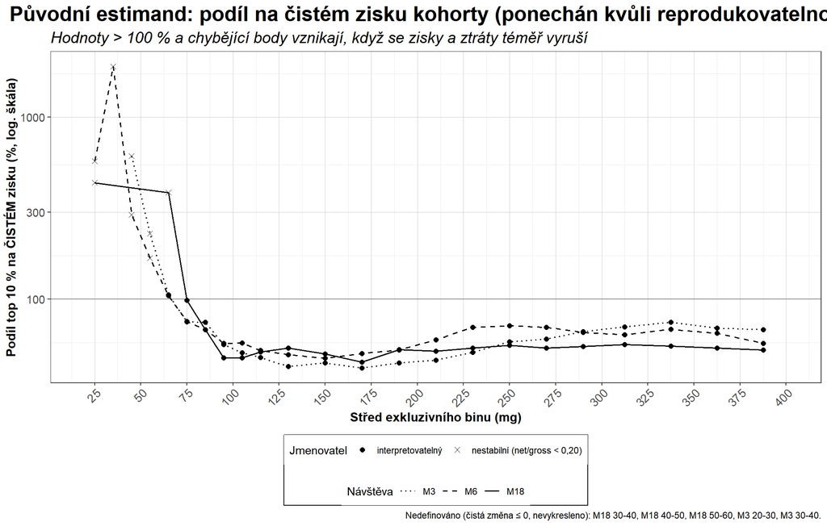

**Původní estimand, ponechaný kvůli reprodukovatelnosti.** Podíl top 10 % na *čistém* zisku kohorty (panel B prvního reportu) se reprodukuje přesně. Má dvě vady:

- Při čisté změně ≤ 0 je **nedefinovaný**. Proto křivky začínají na různých intenzitách: chybí M3 20–40 mg a M18 30–60 mg.
- Když se zisky a ztráty téměř vyruší, **přesahuje 100 %** (až 1898 % v M6, 30–40 mg). Body označené × mají index net/gross pod 0,20. Tato hranice je pragmatická: podíl na čistém zisku může přesáhnout 100 % vždy, když je index pod 1, takže i hodnoty kolem 100 % v „interpretovatelných“ buňkách (např. 60–80 mg) odrážejí hlavně vyrušení.

Hodnoty nad 100 % nejsou chybou výpočtu: top 10 % získalo víc, než činí čistý zisk celé kohorty, protože jiní pacienti čas ztratili.

C5 — Zachycuje změnu hladké naklopení (intenzitní gradient)?

| Návštěva | n | Průměrná ΔIG | Průměrná Δ průměrného ENMO (mg) | Průměrný sklon clr | Spearman sklon vs ΔIG | Spearman sklon vs Δ ENMO |
| --- | --- | --- | --- | --- | --- | --- |
| M3 | 47 | 0,05 | 3,00 | 0,28 | 0,68 | 0,43 |
| M6 | 52 | 0,08 | 3,13 | 0,25 | 0,69 | 0,53 |
| M18 | 39 | 0,11 | 2,67 | 0,22 | 0,71 | 0,62 |

**Co ukazuje.**

- Zda se „naklopení“ profilu na úrovni pacienta (z E3) pohybuje společně se zavedenými souhrnnými metrikami: změnou intenzitního gradientu (ΔIG) a změnou průměrného zrychlení (Δ průměrného ENMO).
- Spearmanova korelace 1 by znamenala, že nesou totožnou informaci.

**Hodnocení.**

- Naklopení koreluje středně s ΔIG (ρ ≈ 0,69 v M6) a slaběji s Δ průměrného ENMO (ρ ≈ 0,53).
- Průměrné ENMO vzrostlo v M6 zhruba o 3,1 mg.
- Na úrovni skupiny se obě míry rozcházejí: průměrná ΔIG od M3 do M18 *roste* (0,048 → 0,105), zatímco sklon clr *klesá* (0,277 → 0,218).
- Pravděpodobným důvodem je, že GGIR počítá IG přes širší rozsah (0–4000 mg v binech po 25 mg) než tato analýza (20–400 mg).

**Proč je to zajímavé.**

- IG je blízce příbuzný souhrn téhož naklopení bez prahového bodu. Obě veličiny jsou sklonem log času proti log intenzitě, takže určitá korelace je dána konstrukcí.
- ρ kolem 0,7 znamená, že obě sdílejí jen zhruba polovinu pořadí pacientů a jejich časový průběh se liší.
- IG je proto rozumný, ale **ne rovnocenný** souhrn.
- Pro studie u IIM je dobře zdůvodnitelná kombinace měřítka objemu (průměrné ENMO nebo čas nad konvenčním prahem) a IG. Profil spektra je podrobnější deskriptivní doplněk.

C1 — Liší se tvar změny mezi M3 a M6 (tíž pacienti)?

| Část | Změna clr M6 − M3 | 95% IS | Simult. pás | Pacienti |
| --- | --- | --- | --- | --- |
| <20 | -0,06 | -0,20 až 0,08 | -0,26 až 0,14 | 45 |
| 20-30 | -0,05 | -0,16 až 0,08 | -0,22 až 0,13 | 45 |
| 30-40 | -0,03 | -0,14 až 0,09 | -0,19 až 0,13 | 45 |
| 40-50 | -0,03 | -0,12 až 0,08 | -0,17 až 0,12 | 45 |
| 50-60 | -0,02 | -0,10 až 0,07 | -0,15 až 0,11 | 45 |
| 60-70 | -0,01 | -0,09 až 0,08 | -0,13 až 0,11 | 45 |
| 70-80 | 0,01 | -0,06 až 0,08 | -0,09 až 0,11 | 45 |
| 80-90 | 0,03 | -0,03 až 0,09 | -0,05 až 0,11 | 45 |
| 90-100 | 0,03 | -0,02 až 0,09 | -0,04 až 0,11 | 45 |
| 100-110 | 0,03 | -0,02 až 0,08 | -0,04 až 0,10 | 45 |
| 110-120 | 0,04 | -0,02 až 0,10 | -0,04 až 0,13 | 45 |
| 120-140 | 0,06 | -0,00 až 0,12 | -0,03 až 0,14 | 45 |
| 140-160 | 0,08 | 0,00 až 0,15 | -0,03 až 0,18 | 45 |
| 160-180 | 0,07 | -0,01 až 0,15 | -0,05 až 0,18 | 45 |
| 180-200 | 0,05 | -0,06 až 0,17 | -0,12 až 0,22 | 45 |
| 200-220 | 0,01 | -0,09 až 0,12 | -0,14 až 0,17 | 45 |
| 220-240 | -0,08 | -0,18 až 0,03 | -0,22 až 0,07 | 45 |
| 240-260 | -0,03 | -0,19 až 0,12 | -0,25 až 0,20 | 45 |
| 260-280 | -0,13 | -0,28 až 0,00 | -0,34 až 0,08 | 45 |
| 280-300 | -0,10 | -0,25 až 0,05 | -0,31 až 0,12 | 45 |
| >=300 | 0,11 | -0,08 až 0,28 | -0,14 až 0,36 | 45 |

Předem dané souhrny podle podtypu (kompletní páry; PM a UCTD/SSc vyřazeni; deskriptivně)

| Podtyp | Návštěva | Páry | ΔT100 průměr (min/den) | ΔT100 medián [IQR] | Pacienti se ziskem T100 (%) | Sklon clr průměr | ΔIG průměr |
| --- | --- | --- | --- | --- | --- | --- | --- |
| ASyS | M3 | 14 | 21,83 | 20,9 [-2,1; 43,6] | 64,29 | 0,21 | 0,03 |
| DM | M3 | 17 | 24,22 | 24,6 [-0,5; 42,9] | 70,59 | 0,27 | 0,04 |
| IMNM | M3 | 13 | 8,53 | 5,7 [-5,0; 20,5] | 61,54 | 0,32 | 0,07 |
| ASyS | M6 | 15 | 33,86 | 24,2 [0,9; 62,0] | 73,33 | 0,16 | 0,01 |
| DM | M6 | 18 | 23,50 | 24,4 [1,5; 45,5] | 72,22 | 0,29 | 0,08 |
| IMNM | M6 | 15 | 5,08 | 3,0 [-3,6; 14,9] | 66,67 | 0,28 | 0,13 |
| ASyS | M18 | 12 | 22,94 | 21,1 [3,4; 41,4] | 75,00 | 0,17 | 0,05 |
| DM | M18 | 14 | 31,02 | 38,8 [-5,1; 65,0] | 64,29 | 0,30 | 0,16 |
| IMNM | M18 | 13 | 1,67 | -5,9 [-9,6; 14,1] | 46,15 | 0,18 | 0,10 |

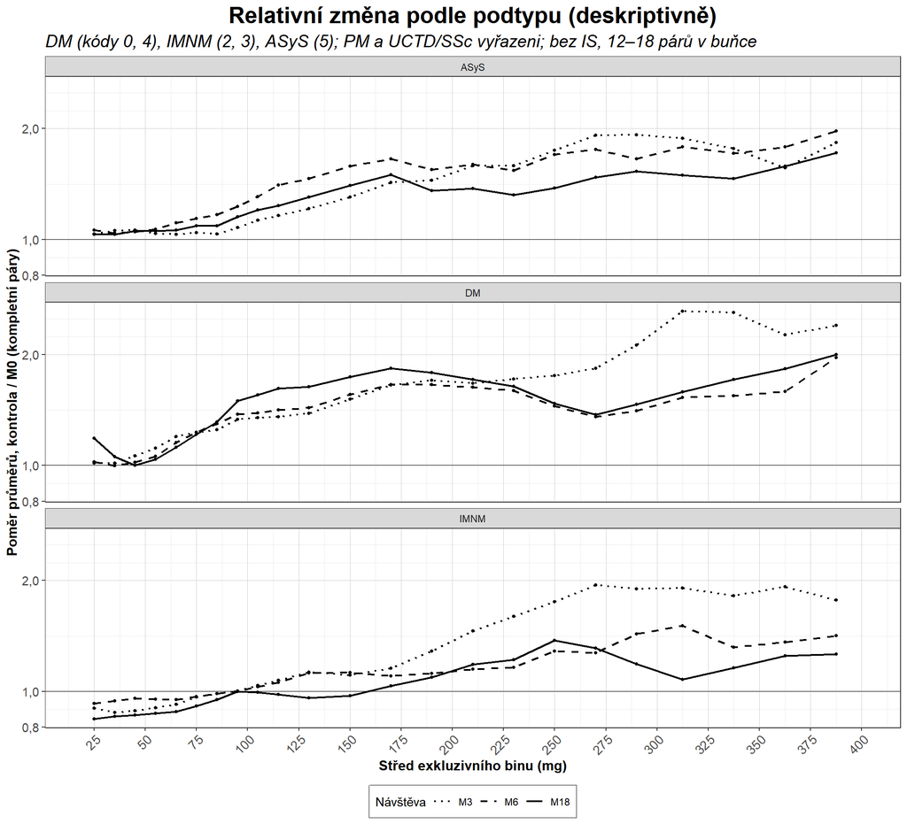

**Co ukazuje.**

- Tři předem dané souhrny pro každý podtyp:
  - změnu času nad 100 mg (průměr, medián s IQR, % pacientů se ziskem);
  - sklon clr na úrovni pacienta;
  - změnu IG.
- F7 ukazuje úplný relativní profil bin po binu pro každý podtyp.
- Čistě deskriptivně: bez IS a bez testů, 12–18 párů na podtyp a návštěvu.

**Hodnocení.**

- Souhrny se mezi DM, IMNM a ASyS liší velikostí.
- V rámci každého podtypu ukazují mediány a IQR velkou individuální variabilitu; malý průměr tedy neznamená, že se žádný pacient nezlepšil.

**Proč je to zajímavé.**

- Rozdíly v obnově denní aktivity mezi podtypy myozitid jsou klinicky věrohodné. Při těchto velikostech vzorků ale může jakýkoli rozdíl vzniknout náhodou, výchozí závažností, délkou nemoci nebo léčbou.
- Předem specifikovaná analýza podtypů s dostatečnou silou a adjustací na tyto faktory je přirozeným dalším krokem.

**Pozor:** Z této tabulky ani figury nelze vyvozovat závěry o efektu podtypu. Jakýkoli jednotlivý bin nebo podtyp vyzdvižený až po pohledu na data by byl post-hoc výběrem.

### Podtypy s adjustací na výchozí závažnost (A07-E, exploratorně)

**Zdroj dat.** Výchozí klinické proměnné nejsou součástí uzamčeného master datasetu. Pocházejí ze souboru `klinicka_data_12102026.xlsx`; jeho md5 je uložen v logu skriptu 09. Napojilo se všech 71 pacientů a kódy podtypů souhlasí u každého pacienta, který má kód v obou zdrojích.

Dostupnost výchozích ukazatelů závažnosti (M0) u pacientů s párem s kontrolou

| Podtyp | Pacienti | Se záznamem M0 | S ≥ 1 párem s kontrolou | … a ph_VAS | … a MMT8 | … a FI2 |
| --- | --- | --- | --- | --- | --- | --- |
| ASyS | 22 | 21 | 17 | 14 | 15 | 15 |
| DM | 24 | 20 | 18 | 18 | 18 | 14 |
| IMNM | 20 | 17 | 16 | 15 | 15 | 13 |
| PM / UCTD (vyřazeni) | 5 | 5 | 4 | 4 | 4 | 3 |

Výchozí závažnost podle podtypu: medián [IQR] (n), pacienti s párem s kontrolou

| Podtyp | ph_VAS (mm) | MDAAT svalová VAS | Extramuskulární VAS | MMT8 (0–80) | FI2 | HAQ | Trvání nemoci (roky) | GK (mg/den) |
| --- | --- | --- | --- | --- | --- | --- | --- | --- |
| ASyS | 41,0 [22,8; 53,8] (n=14) | 25,0 [8,8; 37,8] (n=14) | 42,5 [22,2; 57,8] (n=14) | 75,0 [68,0; 80,0] (n=15) | 37,3 [23,6; 60,3] (n=15) | 1,2 [0,3; 1,6] (n=16) | 0,4 [0,2; 1,0] (n=17) | 40,0 [20,0; 45,0] (n=17) |
| Všichni (vč. PM/UCTD) | 43,0 [31,0; 56,5] (n=51) | 34,0 [18,0; 53,0] (n=51) | 24,5 [11,5; 50,8] (n=50) | 70,0 [63,0; 76,0] (n=52) | 29,4 [13,5; 38,6] (n=45) | 1,0 [0,5; 1,6] (n=52) | 0,4 [0,2; 1,0] (n=55) | 30,0 [20,0; 40,0] (n=55) |
| DM | 44,5 [35,0; 53,0] (n=18) | 29,5 [18,0; 47,5] (n=18) | 45,0 [27,2; 53,8] (n=18) | 71,5 [67,0; 76,8] (n=18) | 34,3 [12,1; 40,5] (n=14) | 1,1 [0,4; 1,9] (n=17) | 0,4 [0,2; 0,9] (n=18) | 30,0 [20,0; 40,0] (n=18) |
| IMNM | 49,0 [33,0; 58,0] (n=15) | 54,0 [35,5; 67,0] (n=15) | 2,0 [0,0; 12,2] (n=14) | 63,0 [58,5; 68,0] (n=15) | 19,7 [13,5; 28,3] (n=13) | 0,9 [0,8; 1,3] (n=15) | 0,5 [0,2; 1,0] (n=16) | 30,0 [23,8; 32,5] (n=16) |

Co ph_VAS měří v jednotlivých podtypech? (Spearmanovy korelace v M0)

| Podtyp | n | ρ ph_VAS – svalová VAS | ρ ph_VAS – extramuskulární VAS | ρ ph_VAS – MMT8 | Medián svalové VAS | Medián extramuskulární VAS |
| --- | --- | --- | --- | --- | --- | --- |
| DM | 18 | 0,38 | 0,51 | -0,02 | 29,5 | 45,0 |
| IMNM | 15 | 0,97 | 0,62 | -0,55 | 54,0 | 2,0 |
| ASyS | 14 | 0,70 | 0,87 | -0,14 | 25,0 | 42,5 |

**Je ph_VAS pro tuto otázku vhodným měřítkem výchozí aktivity nemoci?**

- Lékařovo globální hodnocení aktivity (ph_VAS) shrnuje *veškerou* aktivitu nemoci: svaly, kůži, plíce, klouby i celkové příznaky. Co ho určuje, se mezi podtypy liší:
  - u **IMNM** je to téměř čistě svalová aktivita (ρ se svalovou VAS 0,97; medián extramuskulární VAS ≈ 2 mm);
  - u **DM** a **ASyS** je z podstatné části určené extramuskulární aktivitou (ρ s extramuskulární VAS 0,51 a 0,87 oproti 0,38 a 0,70 se svalovou VAS; n = 14–18) a se svalovou silou prakticky nesouvisí (ρ s MMT8 ≈ 0).
- Stejná hodnota ph_VAS proto znamená u DM/ASyS **menší svalové postižení než u IMNM**. Jako adjustace na to, „jak omezená byla na začátku pacientova mobilita“, je ph_VAS nedokonalé, a to v různých podtypech různě. MMT8 je přímější měřítko svalového postižení, a proto slouží jako citlivostní analýza.
- **Kolinearita.** ph_VAS se mezi podtypy téměř neliší (R² na podtyp 0,04, VIF 1,04). MMT8 je u IMNM nižší (R² 0,17, VIF 1,20). MMT8 a FI2 spolu silně korelují (ρ = 0,82 v analyzovaném vzorku), proto se FI2 do modelů s MMT8 nepřidává; FI2 má navíc nejvíc chybějících hodnot.

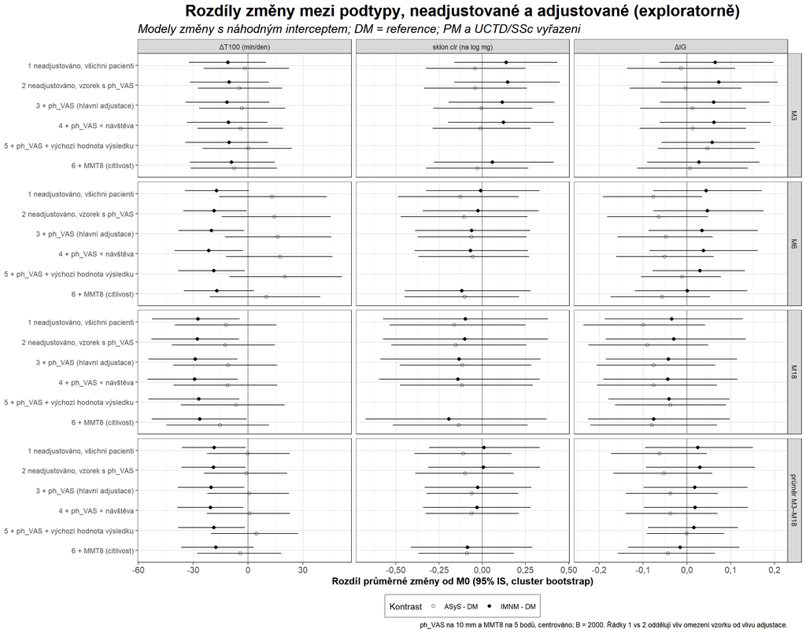

Testy věrohodnostním poměrem (ML, náhodný intercept; exploratorně, bez korekce na multiplicitu)

| Výsledek | Závažnost | Test | χ² | df | p | Pacienti | Pozorování |
| --- | --- | --- | --- | --- | --- | --- | --- |
| ΔT100 | ph_VAS | interakce podtyp × návštěva | 8,321 | 4 | 0,081 | 47 | 126 |
| ΔT100 | ph_VAS | jakýkoli efekt podtypu (hlavní + interakce) | 13,505 | 6 | 0,036 | 47 | 126 |
| ΔT100 | ph_VAS | interakce závažnost × návštěva | 4,719 | 2 | 0,094 | 47 | 126 |
| ΔT100 | ph_VAS | hlavní efekt závažnosti | 1,838 | 1 | 0,175 | 47 | 126 |
| ΔT100 | MMT8 | interakce podtyp × návštěva | 7,199 | 4 | 0,126 | 48 | 127 |
| ΔT100 | MMT8 | jakýkoli efekt podtypu (hlavní + interakce) | 9,922 | 6 | 0,128 | 48 | 127 |
| ΔT100 | MMT8 | interakce závažnost × návštěva | 1,616 | 2 | 0,446 | 48 | 127 |
| ΔT100 | MMT8 | hlavní efekt závažnosti | 0,137 | 1 | 0,712 | 48 | 127 |
| sklon clr | ph_VAS | interakce podtyp × návštěva | 2,395 | 4 | 0,664 | 47 | 126 |
| sklon clr | ph_VAS | jakýkoli efekt podtypu (hlavní + interakce) | 2,564 | 6 | 0,861 | 47 | 126 |
| sklon clr | ph_VAS | interakce závažnost × návštěva | 1,361 | 2 | 0,506 | 47 | 126 |
| sklon clr | ph_VAS | hlavní efekt závažnosti | 5,663 | 1 | 0,017 | 47 | 126 |
| sklon clr | MMT8 | interakce podtyp × návštěva | 2,397 | 4 | 0,663 | 48 | 127 |
| sklon clr | MMT8 | jakýkoli efekt podtypu (hlavní + interakce) | 2,906 | 6 | 0,821 | 48 | 127 |
| sklon clr | MMT8 | interakce závažnost × návštěva | 1,824 | 2 | 0,402 | 48 | 127 |
| sklon clr | MMT8 | hlavní efekt závažnosti | 3,575 | 1 | 0,059 | 48 | 127 |
| ΔIG | ph_VAS | interakce podtyp × návštěva | 5,491 | 4 | 0,241 | 47 | 126 |
| ΔIG | ph_VAS | jakýkoli efekt podtypu (hlavní + interakce) | 6,376 | 6 | 0,382 | 47 | 126 |
| ΔIG | ph_VAS | interakce závažnost × návštěva | 0,326 | 2 | 0,849 | 47 | 126 |
| ΔIG | ph_VAS | hlavní efekt závažnosti | 5,062 | 1 | 0,024 | 47 | 126 |
| ΔIG | MMT8 | interakce podtyp × návštěva | 5,598 | 4 | 0,231 | 48 | 127 |
| ΔIG | MMT8 | jakýkoli efekt podtypu (hlavní + interakce) | 6,207 | 6 | 0,400 | 48 | 127 |
| ΔIG | MMT8 | interakce závažnost × návštěva | 1,434 | 2 | 0,488 | 48 | 127 |
| ΔIG | MMT8 | hlavní efekt závažnosti | 5,790 | 1 | 0,016 | 48 | 127 |

**Co ukazuje.**

- Modely změny od M0 v M3, M6 a M18 pro tři předem dané souhrny; žádný jednotlivý bin se nevybírá:
  - ΔT100 (min/den nad 100 mg);
  - sklon clr na úrovni pacienta (souhrn „tvaru“);
  - ΔIG (změna intenzitního gradientu).
- Referencí je DM. Kontrasty se vyhodnocují při průměrné závažnosti, pro každou návštěvu i v průměru přes návštěvy („průměr M3–M18“), s 95% IS z pacientského cluster bootstrapu (B = 2000).
- Jak číst řádky figury:
  - **řádek 1:** bez adjustace, všichni pacienti s podtypem;
  - **řádek 2:** bez adjustace, jen pacienti s ph_VAS. Srovnání řádků 1 a 2 ukazuje, co udělá samotné *omezení vzorku*;
  - **řádky 3–5:** adjustace na ph_VAS; + ph_VAS × návštěva; + výchozí hodnota výsledku;
  - **řádek 6:** adjustace na MMT8 místo ph_VAS.
- Zhruba 12–18 pacientů na podtyp a návštěvu.

**Hodnocení (exploratorně).**

**Jak s tím naložit.**

- Jde o odhady generující hypotézy: tři výsledky, dvě měřítka závažnosti a několik modelů, bez korekce na multiplicitu a s 12–18 pacienty v buňce.
- Testy věrohodnostním poměrem s fity ML na zhruba 47 pacientech jsou poněkud antikonzervativní; kde se rozcházejí s bootstrapovými intervaly (např. MMT8 → ΔIG), je opatrnějším vodítkem bootstrap. V modelu E_c se koeficient závažnosti vztahuje k M3 (referenční návštěva členu závažnost × návštěva).
- Jediným signálem, který stojí za ověření v nezávislé kohortě, je rozdíl IMNM vs DM v *objemu* (ΔT100), ideálně s výchozí svalovou silou předem specifikovanou jako kovariáta. Trvání nemoci a dávka glukokortikoidů jsou uvedeny, ale kvůli riziku přeučení nejsou modelovány.
- Nic z toho neidentifikuje biologicky odlišnou podskupinu responderů.

### Liší se tvar změny mezi kontrolami? (A07-D)

Tabulku C1 výše (M6 − M3, bin po binu, původní analýza) kód revize přesně reprodukuje (validace R9b). Revize doplňuje formální párová srovnání pro všechny tři páry návštěv.

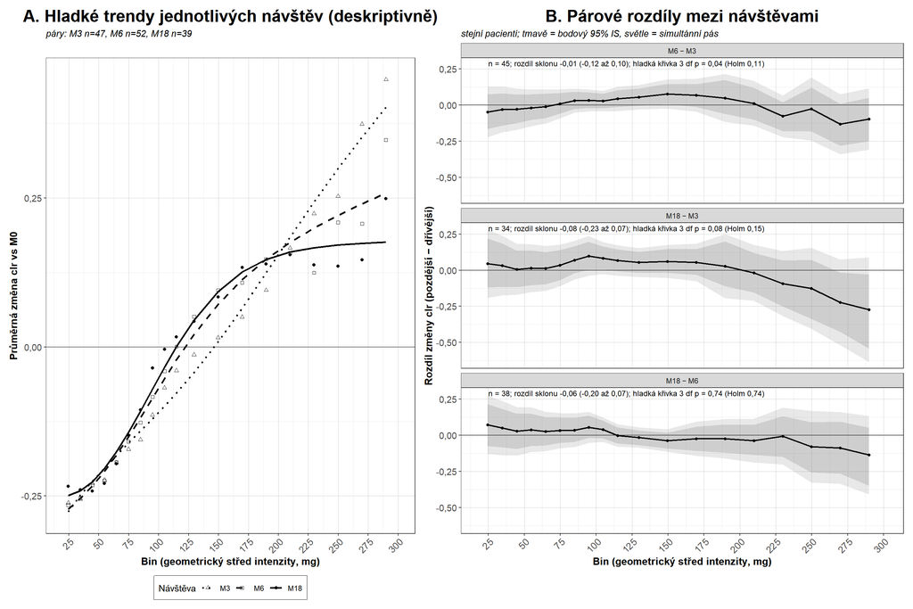

Párové srovnání tvaru změny mezi kontrolami (cluster bootstrap, B = 2000)

| Kontrast | Vzorek | Pacienti | Rozdíl sklonu (95% IS) | p sklonu (Holm) | Wald hladké křivky (3 df) | p hladké křivky, bootstrap (Holm) | Biny mimo simult. pás |
| --- | --- | --- | --- | --- | --- | --- | --- |
| M6 − M3 | všichni s M0 a oběma návštěvami | 45 | -0,01 (-0,12 až 0,10) | 0,905 (0,905) | 8,3 | 0,037 (0,111) | 0 |
| M6 − M3 | společný vzorek (všechny 4 návštěvy) | 34 | 0,03 (-0,09 až 0,14) | 0,689 (0,689) | 9,7 | 0,024 (0,071) | 0 |
| M18 − M3 | všichni s M0 a oběma návštěvami | 34 | -0,08 (-0,23 až 0,07) | 0,296 (0,888) | 7,1 | 0,076 (0,153) | 0 |
| M18 − M3 | společný vzorek (všechny 4 návštěvy) | 34 | -0,08 (-0,23 až 0,07) | 0,296 (0,592) | 7,1 | 0,076 (0,153) | 0 |
| M18 − M6 | všichni s M0 a oběma návštěvami | 38 | -0,06 (-0,20 až 0,07) | 0,344 (0,888) | 1,2 | 0,742 (0,742) | 0 |
| M18 − M6 | společný vzorek (všechny 4 návštěvy) | 34 | -0,10 (-0,25 až 0,02) | 0,124 (0,373) | 5,7 | 0,128 (0,153) | 0 |

**Co ukazuje.**

- **Panel A (jen deskriptivně):** tři hladké trendy jednotlivých návštěv z F3 přes sebe. Vycházejí z různých souborů pacientů (M3 n = 47; M6 n = 52; M18 n = 39 párů), takže vizuální rozdíly mohou odrážet, kdo na návštěvu přišel, stejně jako to, jak se změnil.
- **Panel B a tabulka:** formální test. U týchž pacientů (M0 plus obě návštěvy) se rozdíl změny clr „pozdější minus dřívější“ analyzuje třemi způsoby:
  - bin po binu se simultánním pásem;
  - jako rozdíl lineárního *sklonu*;
  - 3-df testem, že hladká křivka rozdílu je plochá, tj. že *tvar* v rozsahu 20–300 mg je stejný až na konstantní posun (konstantní posun, odrážející výměnu s částmi <20 a ≥300 mg, se záměrně netestuje).
- P-hodnoty jsou Holm-korigované přes tři páry. Citlivostní analýza vše opakuje u 34 pacientů se všemi čtyřmi návštěvami.

**Hodnocení.**

- **Panel A vypadá mezi návštěvami odlišně:**
  - M3 je téměř přímé naklopení, které stoupá až k 300 mg;
  - M6 a M18 se nad ~175 mg ohýbají a zplošťují.
- **Formální testy po korekci na multiplicitu rozdíl nepotvrzují:**
  - **Sklon:** žádný pár návštěv se neliší (M6 − M3: -0,01, 95% IS -0,12 až 0,10; všechna p po Holmovi ≥ 0,89).
  - **Celkový tvar:** M6 vs M3 ukazuje nominální rozdíl zakřivení (p = 0,037, Holm 0,111; ve společném vzorku p = 0,024, Holm 0,071, tedy hraničně). M18 vs M3 dává p = 0,076 (Holm 0,153) a M18 vs M6 rozdíl neukazuje (p = 0,742).
  - **Bin po binu:** v žádném srovnání neleží žádný bin mimo simultánní pás.
- **Závěr.** Plošší konec vysokých intenzit v M6/M18 oproti M3 je **deskriptivní vzorec slučitelný s časným „výbuchem“, který se ustálí**, ne statisticky podložený rozdíl mezi fázemi zotavení. Bodové odhady M18 − M3 v rozsahu 250–300 mg (−0,2 až −0,3) jsou velké, ale nepřesné (34 pacientů).

Časování a sezóna srovnávaných návštěv

| Kontrast | Pacienti | Dřívější návštěva: měsíce od M0, medián (rozsah) | Pozdější návštěva: měsíce od M0, medián (rozsah) | Odstup, medián (měsíce) | Stejná sezóna, dřívější vs pozdější (%) | Stejná sezóna jako M0, dřívější (%) | Stejná sezóna jako M0, pozdější (%) |
| --- | --- | --- | --- | --- | --- | --- | --- |
| M6 − M3 | 45 | 3,2 (2,0-6,0) | 6,6 (5,0-9,4) | 3,2 | 2 | 4 | 0 |
| M18 − M3 | 34 | 3,2 (2,0-6,0) | 19,6 (16,5-21,8) | 15,9 | 0 | 3 | 0 |
| M18 − M6 | 38 | 6,6 (5,0-9,4) | 19,5 (16,5-21,8) | 12,4 | 71 | 0 | 0 |

**Proč nelze rozdíly mezi návštěvami oddělit od ročního období a časování.**

- **Sezóna.** Téměř žádný pacient není v M0 a při kterékoli kontrole zaznamenán ve stejné sezóně: v M6 a M18 0 %, v M3 několik procent. Srovnání M3 → M6 téměř vždy překračuje sezónu (2 % ve stejné sezóně), zatímco M6 a M18 spadají do stejné sezóny u 71 % pacientů. Sezóna je tedy s návštěvou svázaná už designem a v kontrastech tvaru ji nelze adjustovat.
- **Časování.** M3 (2–6 měsíců) a M6 (5–9 měsíců) se ve skutečném čase od výchozího měření překrývají. „M3 vs M6“ znamená *časná vs pozdější kontrola*, ne přesné časové body.
- **Kdo přišel.** Páry se liší tím, kdo je v nich zahrnut; společný vzorek dává podobný, o něco silnější, ale po Holmovi stále nevýznamný signál M6 vs M3. Pacienti bez M0 jsou vyřazeni kvůli konzistenci s E3, přestože se M0 v rozdílu návštěv odečte.

# 9 Robustnost, výsledky validace a záznam problémů

## Citlivostní analýzy

Shoda citlivostních analýz s primárními odhady E1/E2

| Estimand | Blok | Citlivostní analýza | n | Stejné znaménko jako primární (%) | Uvnitř primárního 95% IS (%) |
| --- | --- | --- | --- | --- | --- |
| E1 | biny | S1 kompletní páry | 69 | 94,2 | 100 |
| E1 | biny | S2 náhodný intercept | 69 | 98,6 | 100 |
| E1 | biny | S7 ≥ 5 validních dnů | 69 | 98,6 | 100 |
| E1 | biny | S8 bez UCTD/SSc | 69 | 98,6 | 100 |
| E1 | kumulativní | S1 kompletní páry | 72 | 100,0 | 100 |
| E1 | kumulativní | S2 náhodný intercept | 72 | 100,0 | 100 |
| E1 | kumulativní | S7 ≥ 5 validních dnů | 72 | 100,0 | 100 |
| E1 | kumulativní | S8 bez UCTD/SSc | 72 | 100,0 | 100 |
| E2 | biny | S1 kompletní páry | 69 | 94,2 | 100 |
| E2 | biny | S2 náhodný intercept | 69 | 98,6 | 100 |
| E2 | biny | S7 ≥ 5 validních dnů | 69 | 98,6 | 100 |
| E2 | biny | S8 bez UCTD/SSc | 69 | 98,6 | 100 |
| E2 | kumulativní | S1 kompletní páry | 72 | 100,0 | 100 |
| E2 | kumulativní | S2 náhodný intercept | 72 | 100,0 | 100 |
| E2 | kumulativní | S7 ≥ 5 validních dnů | 72 | 100,0 | 100 |
| E2 | kumulativní | S8 bez UCTD/SSc | 72 | 100,0 | 100 |

**Hodnocení.**

- Při alternativních analýzách si odhady zachovávají směr v 94–100 % binů a ve 100 % binů zůstávají uvnitř primárního 95% IS. Alternativami jsou: jen kompletní páry, jednodušší model s náhodným interceptem, ≥ 5 validních dnů a vyřazení pacienta s UCTD/SSc.
- **Hlavní výsledky jsou při těchto analytických volbách konzistentní.** Setrvání uvnitř primárního IS je slabý doklad, protože všechny varianty sdílejí většinu dat.

Kotevní test sezónnosti (společný 2-df LRT ročních harmonických, opravený)

| Blok | Deskriptor | Pozorování | Pacienti | Pozorované měsíce | LR χ² | LR df | LR p | β sin | β cos |
| --- | --- | --- | --- | --- | --- | --- | --- | --- | --- |
| kumulativní | T100 | 217 | 71 | 12 | 4,109 | 2 | 0,128 | 0,021 | -0,076 |
| biny | 100-110 | 217 | 71 | 12 | 3,853 | 2 | 0,146 | 0,024 | -0,049 |

**Co ukazuje.** Test, zda roční období (roční sinusový/kosinusový cyklus) vysvětluje část úrovně aktivity. Provádí se pro čas nad 100 mg a pro bin 100–110 mg.

**Hodnocení.**

- Doklad sezónního efektu není (p ≈ 0,13). Modely adjustované na sezónu daly prakticky stejné efekty návštěv.
- Dříve prázdný list sezónnosti v A04/A07 způsobovala chyba v kódu, která je nyní opravena.

**Pozor:** Návštěvy jsou svázané s kalendářem: žádný pár M0→M6 nespadá do stejné sezóny. Sezónní efekty a efekty léčby proto nelze plně oddělit a nulový výsledek sezónního testu nevylučuje mírný příspěvek sezóny.

S9 — O kolik horší by musely být chybějící hodnoty M18, aby zisk M0→M18 zmizel?

| Bin | Pacienti s M0 | Imputované M18 | δ: bodový odhad → 0 | δ: dolní mez 95% IS → 0 |
| --- | --- | --- | --- | --- |
| 100-110 | 63 | 24 | 6,65 | 1,65 |
| 110-120 | 63 | 24 | 5,72 | 1,49 |
| 120-140 | 63 | 24 | 4,41 | 1,14 |
| 140-160 | 63 | 24 | 3,24 | 1,12 |
| 160-180 | 63 | 24 | 2,45 | 0,99 |
| 180-200 | 63 | 24 | 1,65 | 0,66 |
| 20-30 | 63 | 24 | -3,60 | -27,90 |
| 200-220 | 63 | 24 | 1,13 | 0,43 |
| 220-240 | 63 | 24 | 0,75 | 0,26 |
| 240-260 | 63 | 24 | 0,59 | 0,20 |
| 260-280 | 63 | 24 | 0,39 | 0,11 |
| 280-300 | 63 | 24 | 0,28 | 0,07 |
| 30-40 | 63 | 24 | -5,41 | -20,01 |
| 300-325 | 63 | 24 | 0,18 | 0,03 |
| 325-350 | 63 | 24 | 0,14 | 0,02 |
| 350-375 | 63 | 24 | 0,13 | 0,03 |
| 375-400 | 63 | 24 | 0,11 | 0,01 |
| 40-50 | 63 | 24 | -4,29 | -14,71 |
| 50-60 | 63 | 24 | -1,61 | -10,08 |
| 60-70 | 63 | 24 | 0,91 | -6,71 |
| 70-80 | 63 | 24 | 3,63 | -3,22 |
| 80-90 | 63 | 24 | 5,01 | -1,31 |
| 90-100 | 63 | 24 | 7,17 | 1,51 |

**Co ukazuje.**

- Zhruba 4 z 10 pacientů s výchozím měřením nemají záznam M18.
- Tipping point udává, o kolik *horší* by jejich nepozorované hodnoty M18 musely být oproti modelové predikci, aby zisk M0→M18 zmizel.

**Hodnocení.**

- Aby *bodový odhad* dosáhl nuly, museli by chybějící pacienti ztratit zhruba 1,6násobek toho, co pozorovaní pacienti získali. Tento poměr je dán podílem chybějících M18 (24 z 63), sám o sobě tedy informativní není.
- Relevantnější otázkou je, kdy zisk v M18 přestane být *statisticky podložený*, tedy kdy dolní mez 95% IS dosáhne nuly.
  - Pro 90–100 mg k tomu dojde už při posunu zhruba 1,5 min/den na 10 mg u chybějících pacientů.
  - Pro čas nad 100 mg zhruba při 17,7 min/den.
- To jsou mírné posuny. Možnými důvody horšího výsledku u nedostavivších se pacientů jsou relaps, hospitalizace nebo progrese ILD, takže **výsledek M18 je citlivý na věrohodné odchylky od MAR**. Důvody vynechaných návštěv je třeba sbírat.

## Validace (PASS/WARN/FAIL)

Výsledky validačního plánu

| ID | Kontrola | Stav | Detail (technický výpis) |
| --- | --- | --- | --- |
| V1 | Kontroly integrity dat (D1–D19) | PASS | 10 PASS, 4 WARN, 0 FAIL |
| V2 | Párová změna: kumulativní T = součet binů ≥ T + (≥ 400) | PASS | max &#124;error&#124; = 3.55e-15 min/day (identity holds for complete pairs; MMRM per descriptor is not additive by construction) |
| V3 | Kompozice se uzavírá na 1440 min (surově i po náhradě nul); biny = nativní hrany GGIR | PASS | max &#124;sum-1440&#124; raw 0.0e+00, replaced 0.0e+00; 21 parts |
| V4 | Reprodukovatelnost: stejný vstup = stejné odhady; bootstrap 1 vs N workerů shodný | PASS | estimates identical: TRUE; 1 vs 4 workers identical: TRUE; seed 20261013 |
| V5a | Konvergence MMRM napříč bootstrapovými replikacemi | PASS | replicate x visit fits: random-intercept fallback 0, failed 0 (see fit_log) |
| V5b | Rozdělení reziduí (RI LMM, po binech) | WARN | max &#124;skewness&#124; 5.07, max excess kurtosis 43.1, max Spearman(&#124;r&#124;, fitted) 0.57 -> uncertainty from cluster bootstrap, not Wald |
| V6 | Vliv vynechání jednoho pacienta na E1 (v jednotkách SE) | PASS | max shift 0.93 SE (median 0.47 SE); bins/visits with shift > 1 SE: 0 |
| V7a | Maticový výpočet E3 = est_E3() (pozorovaná rezidua) | PASS | max &#124;difference&#124; = 2.9e-16 |
| V7 | Síla pravidla hrbu E3, plasmode se skutečným nullem (N_SIM = 500, B_SIM = 1000) | INFO | 2 bins 120-160, +0.2 M3: 100%; 2 bins 120-160, +0.2 M6: 100%; 2 bins 120-160, +0.2 M18: 97%; 2 bins 120-160, +0.1 M3: 68%; 2 bins 120-160, +0.1 M6: 77%; 2 bins 120-160, +0.1 M18: 35%; 3 bins 180-240, … |
| V7b | Chyba I. druhu pravidla hrbu při skutečném nullu (nominálně ≤ 5 %) | PASS | M3: 2.0% (MC 95% CI 1-4); M6: 0.6% (MC 95% CI 0-2); M18: 0.8% (MC 95% CI 0-2) |

**Co ukazuje.** Automatické kontroly výpočtů:

- aritmetické identity;
- reprodukovatelnost (stejný výsledek na 1 i na mnoha jádrech CPU);
- konvergenci modelů (všechny modely konvergovaly);
- rozdělení reziduí;
- vliv jednotlivých pacientů.

**Hodnocení.**

- Všechny technické kontroly prošly.
- Rezidua jsou šikmá (WARN), což se u minut za den očekává. Proto všechny intervaly spolehlivosti pocházejí z pacientského bootstrapu, ne z modelových vzorců.
- Žádný jednotlivý pacient neposune žádný odhad o víc než zhruba jednu směrodatnou chybu.

Síla pravidla hrbu E3 v plasmode (hrb vložený při kontrole)

| Scénář | Návštěva | Simulace | Označen jakýkoli hrb (%) | Vložený hrb detekován (%) |
| --- | --- | --- | --- | --- |
| null (skutečný null) | M3 | 500 | 2 |  |
| null (skutečný null) | M6 | 500 | 1 |  |
| null (skutečný null) | M18 | 500 | 1 |  |
| 2 biny 120–160, +0,2 | M3 | 500 | 100 | 100 |
| 2 biny 120–160, +0,2 | M6 | 500 | 100 | 100 |
| 2 biny 120–160, +0,2 | M18 | 500 | 99 | 97 |
| 2 biny 120–160, +0,1 | M3 | 500 | 73 | 68 |
| 2 biny 120–160, +0,1 | M6 | 500 | 79 | 77 |
| 2 biny 120–160, +0,1 | M18 | 500 | 37 | 35 |
| 3 biny 180–240, +0,2 | M3 | 500 | 93 | 88 |
| 3 biny 180–240, +0,2 | M6 | 500 | 100 | 100 |
| 3 biny 180–240, +0,2 | M18 | 500 | 93 | 87 |
| 4 biny 80–120, +0,2 | M3 | 500 | 100 | 100 |
| 4 biny 80–120, +0,2 | M6 | 500 | 100 | 100 |
| 4 biny 80–120, +0,2 | M18 | 500 | 100 | 100 |
| 4 biny 80–120, +0,1 | M3 | 500 | 95 | 92 |
| 4 biny 80–120, +0,1 | M6 | 500 | 99 | 98 |
| 4 biny 80–120, +0,1 | M18 | 500 | 79 | 75 |
| 6 binů 70–140, +0,2 | M3 | 500 | 100 | 100 |
| 6 binů 70–140, +0,2 | M6 | 500 | 100 | 100 |
| 6 binů 70–140, +0,2 | M18 | 500 | 100 | 100 |
| 6 binů 70–140, +0,1 | M3 | 500 | 74 | 53 |
| 6 binů 70–140, +0,1 | M6 | 500 | 94 | 76 |
| 6 binů 70–140, +0,1 | M18 | 500 | 71 | 49 |

**Co ukazuje.**

**Hodnocení.**

- **Falešné poplachy při skutečném nullu:** M3 2,0 % (MC 95% IS 1-4 %); M6 0,6 % (MC 95% IS 0-2 %); M18 0,8 % (MC 95% IS 0-2 %). Kalibrované pravidlo je drží na nominálních 5 % nebo pod nimi.
- **Velké odchylky (+22 %) se odhalí spolehlivě**, úzké i široké:
  - 2 biny v 120–160 mg: 97–100 %;
  - 3 biny v 180–240 mg: 87–100 %;
  - 4 biny v 80–120 mg: 100 %;
  - 6 binů v 70–140 mg: 100 %.
- **Malé odchylky (+10 %) se odhalí méně spolehlivě**, nejméně v M18 (n = 39):
  - 2 biny: 35–77 %;
  - 4 biny: 75–98 %;
  - 6 binů: 49–76 %.
  - U širokých malých hrbů část odchylky pohltí hladký null.
- **Pravidlo nepředetekuje**: falešné poplachy zůstaly na nominálních 5 % nebo pod nimi i v M18 (n = 39). To kalibruje pravidlo hrbu; samo o sobě to neověřuje pokrytí každého jednotlivého simultánního pásu.
- **Závěr k rozsahu:** nepřítomnost lokálního pásma je dobře podložená pro odchylky zhruba +22 % a větší. Odchylky kolem +10 %, zejména široké nebo v M18, vyloučit nelze a při označení mohou být chybně lokalizovány: u 6binového hrbu +10 % byl *nějaký* hrb označen častěji, než se označení překrývalo s vloženými biny.

## Validace revize A07

Validace revize A07 (10_REV_VALIDATION_BOTH.R)

| ID | Kontrola | Stav | Detail (technický výpis) |
| --- | --- | --- | --- |
| R1 | Exkluzivní biny rekonstruované z kumulativních prahů (D8–D12) | PASS | D8 PASS 0 violations; D9 PASS max &#124;error&#124; = 0.00e+00; D10 PASS max &#124;error&#124; = 0.00e+00; D11 PASS max &#124;error&#124; = 2.84e-14; D12 PASS 0 negative |
| R2 | Šířky binů 10 (20–120), 20 (120–300), 25 (300–400) mg; faktor 10/šířka; normalizovaná = surová × faktor | PASS | 23 bins; widths 10 mg x10, 20 mg x9, 25 mg x4; quantiles per recording = scaled raw quantiles: TRUE |
| R3 | Nemožné / nekonečné hodnoty v revidovaných výstupech | PASS | profile_negative=0; profile_above_1440=0; pct_out_of_0_100=0; net_gross_out_of_range=0; nonfinite_profile=0; nonfinite_conc_except_documented=0; undefined_net_share_cells=5; nonfinite_variants=0; nonf… |
| R4 | Podíly top 10 % přepočítané nezávisle (base R, master bin_long) | PASS | 69 cells; n max diff 0; pct max diff 1.4e-14; share_pos max diff 0; share_net max diff 0; na_pattern max diff 0 |
| R4b | Původní estimand C3 přesně reprodukován kódem revize | PASS | 69 cells; undefined (net <= 0): M18 30-40, M18 40-50, M18 50-60, M3 20-30, M3 30-40 |
| R5 | Uzavření clr (Σ clr = 0), kompozice po náhradě = 1440 min, nuly | PASS | max &#124;sum clr&#124; 5.3e-15; max &#124;sum - 1440&#124; 0.0e+00; 4 of 217 recordings had >= 1 zero part (max share of zeros in a part 3.2%) |
| R5b | Reziduum E3 invariantní vůči centru clr a normalizaci na 10 mg; stejná báze splinu u všech návštěv | PASS | max diff vs saved 2.9e-16, log-minutes vs clr 1.8e-16, per-10 mg vs clr 1.9e-16; identical basis: TRUE |
| R6 | Primární simultánní pásy E3 přepočítané z uložených replikací (base R) | PASS | max &#124;difference&#124; 0.0e+00; B = 2000 |
| R6b | Maticový výpočet a bootstrap revize reprodukovatelné (stejný seed; 1 vs N workerů) | PASS | engine identical: TRUE; 1 vs 4 workers identical: TRUE |
| R6c | Maticový bootstrap (kompletní páry) vs primární (všichni pacienti): reziduum E3 a pološířka pásu | PASS | M3: est diff 3e-16, half-width 0.058 vs 0.056; M6: est diff 3e-16, half-width 0.044 vs 0.043; M18: est diff 3e-16, half-width 0.057 vs 0.059 |
| R7 | Vliv vynechání jednoho pacienta na nové estimandy | WARN | T100/T200 positive-gain share: max shift 6.1 pp; bins >= 240 mg: max 10.9 pp; shape tilt difference: max 0.51 SE; adjusted subtype contrasts: max 0.52 SE (IMNM-DM dT100 sign changes: 0) |
| R7b | Modely podtypů (vzorek s ph_VAS): singulární fity a konvergence | PASS | dT100/E_a_unadjusted: singular FALSE, ICC 0.57; dT100/E_b_sev: singular FALSE, ICC 0.56; dT100/E_c_sev_by_visit: singular FALSE, ICC 0.58; tilt/E_a_unadjusted: singular FALSE, ICC 0.61; tilt/E_b_sev: … |
| R8 | Velikosti vzorků beze změny vůči PŮVODNÍMU výstupu 01 (páry na návštěvu); varianty používají stejné páry; propojení E (hash jen popisný) | PASS | pairs M3=47, M6=52, M18=39; patients in analysis = 71 (hash ac8a06a38422); E: 71/71 master patients linked, subtype codes agree 71/71; ph_VAS model n = 47 |
| R9 | Primární pozorované odhady (E1–E4, všechny bloky) reprodukují uložené originály | PASS | E1 0.0e+00; E2 0.0e+00; E2_avail 0.0e+00; E3_clr 0.0e+00; E3_residual 0.0e+00; E3_residual_linear 0.0e+00; E3_slope 0.0e+00; E4 0.0e+00 |
| R9b | Původní deskriptivní výstupy reprodukovány (surový profil 01, C3 04, C1 04) | PASS | raw profile 92/92 cells; C3 69 cells; C1 max diff 0.0e+00 (19 bounded bins) |
| R10 | Data figur = tabelované výsledky | PASS | A1=TRUE; B1=TRUE; C1=TRUE; D1=TRUE; E1=TRUE |
| R10b | Tvrzení reportu ověřená proti výsledkům | PASS | 9/9 hold; not holding: |

Tvrzení v tomto reportu automaticky ověřená proti výsledkům

| Tvrzení | Platí ve výsledcích |
| --- | --- |
| A: mediány na 10 mg klesají s intenzitou monotónně při každé návštěvě | ano |
| A: surový profil u 120–140 mg při každé návštěvě stoupá (artefakt šířky) | ano |
| B: původní podíl na čistém zisku je v některých nízkých binech nedefinovaný a v jiných > 100 % | ano |
| B: podíl na kladných ziscích zůstává v rozmezí 0–100 % | ano |
| C: žádný hrb při df ≥ 3, váženém fitu ani alternativní mřížce | ano |
| C: chyba I. druhu df 3 ≤ 5 % (dolní mez MC IS) při každé návštěvě pod nullem df 3 | ano |
| D: žádný globální rozdíl tvaru mezi návštěvami po Holmovi (p ≥ 0,05) | ano |
| D: žádný rozdíl sklonu mezi návštěvami po Holmovi (p ≥ 0,05) | ano |
| E: žádná interakce podtyp × návštěva s p < 0,05 (adjustace na ph_VAS, libovolný výsledek) | ano |

**Co ukazuje.**

- Nezávislý přepočet nových čísel samostatným kódem v base R: podíly top 10 %, simultánní pásy z uložených bootstrapových replikací a uzavření clr.
- Reprodukci všech nezměněných primárních a deskriptivních čísel.
- Velikosti vzorků srovnané s původním výstupem; identifikátory pacientů se neukládají.
- Vliv vynechání jednoho pacienta na nové estimandy (včetně binů ≥ 240 mg) a diagnostiku fitů modelů podtypů.
- Shodu figur, tabulek a tvrzení použitých v textu.

WARN označuje výsledek, který je třeba mít na paměti, ne chybu výpočtu. Jediný WARN (R7: podíl top 10 % v binech ≥ 240 mg se při vynechání jednoho pacienta posune až o ~11 procentních bodů) je rozebrán v textu u F6 a v `docs/261016_A07_validation_change_log_summary.md`.

## Záznam problémů

Záznam problémů (audit → oprava → dopad)

| ID | Pozorování | Závažnost | Příčina | Test | Oprava | Dopad |
| --- | --- | --- | --- | --- | --- | --- |
| K1 | Dřívější tvrzení: vrchol M3 ve vysokých intenzitách je artefakt SD | kritická (vědecká) | poloha maxim závisí na škále | profily relativní (E2), dz (E4), clr (E3) | tvrzení staženo; estimandy zvoleny a priori | revidována interpretace H1 |
| K2 | Revidovaný R00 natvrdo používá cestu R:/ a ignoruje MYOII_MASTER_RDS | kritická (reprodukovatelnost) | regrese v revidovaném helperu | revize kódu | nová konfigurace s pořadím hledání + proměnnou prostředí | staré R05/R06 nepřenositelné |
| K3 | List season_anchor_test prázdný v A04/A07 | vysoká | sloupec anova.merMod je Df, ne `Chi Df` | kontrola xlsx + kódu | opraveno v season_anchor_test() | test sezónnosti nyní k dispozici (S5) |
| V1 | Výsledky bootstrapu závisí na počtu workerů (R03/R06) | vysoká | clusterSetRNGStream + parLapply | 1 vs N workerů | výběry generovány předem v hlavním procesu | výsledky přenositelné mezi stroji |
| V2 | Bootstrap v R05 po návštěvě × binu, ne po pacientovi přes spektrum | vysoká | převzorkování v group_modify | revize kódu | jeden výběr pro všechny biny/návštěvy | simultánní pásy nyní platné |
| MO2 | Absolutní vrchol v 120–140 mg je artefakt šířky binu | závažná | biny 10/20/25 mg | normalizace na 10 mg | E1 na 10 mg (v A07 i popisný profil) | absolutní vrchol 90–100 mg |
| MO4 | Nuly soustředěné v M0 v 375–400 mg (14 %) | závažná | řídký chvost | tabulky nul podle návštěvy | ≥ 300 mg sloučeno pro E3; mřížka náhrad | chvost E3 stabilní |
| MO5 | Výpadek do M18 závislý na trajektorii | závažná | observační sledování | S10 | MMRM (MAR) primárně; tipping point S9 | M18 interpretováno s výhradou |
| R1 | Lineární null vytváří rezidua tvaru U | závažná | esovitý profil změny | znaménka pozorovaných reziduí | null z přirozeného splinu, pravidlo hrbu | žádné falešné okrajové „intervaly“ |
| MO9 | Značky L/R zápěstí se u 10 pacientů liší | info | značky v názvech souborů (přístroj podle uživatele vždy na nedominantní ruce) | parsování názvů souborů | žádná (zdokumentováno) | žádný očekávaný |
| R3-5 | „Null“ plasmode převzorkoval pozorovaná data (ne skutečný null); malé N_SIM/B_SIM | závažná | design simulace | plasmode se skutečným nullem, N_SIM 500 × B_SIM 1000, MC IS | V7 přepsáno (maticový výpočet) | chyba I. druhu nyní odhadnutelná |
| R3-6 | Null s df = 3 může pohlcovat široké hrby; detekce porovnávala řetězce hran | závažná | rozlišení hladkého nullu | scénáře se 4 a 6 biny; detekce podle překryvu | rozšířeny scénáře V7 (v A07 i plasmode pro df) | závěr E3 omezen na testované rozlišení |
| R3-7 | Tipping point E/p je mechanická identita | závažná | definice na bodovém odhadu | algebra | reportovat δ, při které dolní mez 95% IS dosáhne 0 | robustnost M18 přeformulována |
| R3-11 | Zvýraznění jednoho binu u IMNM bylo post hoc | závažná | výběr z 23 × 3 × 3 buněk | – | předem dané souhrny podtypů (T100, sklon, dIG) + úplné profily; v A07 adjustované modely | text o podtypech přeformulován |

**Co ukazuje.** Každý problém nalezený v dřívějších analýzách (A04/A07, R01–R06) s jeho příčinou, opravou a dopadem na závěry.

**Nejdůležitější pro interpretaci.** V dřívějších analýzách závisela poloha maxima na škále (jednotky SD, minuty, poměry). Relativní odpověď ve vysokých intenzitách je reálná, ale v absolutních minutách malá; po revizi A07 je její koncentrace mezi pacienty podobná jako ve středních intenzitách (viz F6). Analýza nyní reportuje absolutní, relativní a tvarové estimandy odděleně.

# 10 Biologická a klinická interpretace

**Pozor:** ENMO v mg není metabolická intenzita (MET) a označení „MVPA“ v GGIR neznamená validované kategorie intenzity pro tuto populaci.

- Změny času v binech popisují, *kde na škále zrychlení* denní pohyb přibyl.
- Neukazují, *proč* přibyl: klinická odpověď, sezóna, nebo chování.

Testovatelné hypotézy (exploratorní; k ověření v nezávislých datech):

1. **H1:** Zlepšení u IIM se projevuje hlavně jako **hladké naklopení** denního rozdělení intenzit k vyšším zrychlením, ne jako zisk v jednom konkrétním pásmu intenzity. Malé (~10 %) lokální odchylky tato data vyloučit nedokážou.
2. **H2:** Absolutní minuty přibývají hlavně ve středním pásmu, kde leží většina denního aktivního času. Relativní zisky jsou největší ve vysokých intenzitách, tam ale činí zlomky minuty denně.
3. **H3 (revidováno):** Zisky jsou široké co do směru, ale nerovnoměrné co do velikosti, a to v podobné míře ve středních i vysokých intenzitách (top 10 % ≈ třetina až dvě třetiny kladných zisků). Případná silnější koncentrace časného (M3) zisku ve vysokých intenzitách není formálně podložená. Popisuje to rozdělení změny, ne odlišnou podskupinu responderů.
4. **H4 (revidováno):** Časná odpověď (M3) může být strmějším, lineárnějším naklopením, které se do M6/M18 ve vysokých intenzitách zploští. Deskriptivně je to vidět, párové testy to ale po korekci na multiplicitu nepodporují. Je potřeba to prospektivně otestovat s kontrolou časování návštěv a sezóny.
5. **H5 (nová, exploratorní):** Pacienti s IMNM získávají zpět menší *objem* aktivity (čas nad 100 mg) než pacienti s DM; zda k tomu přispívá výchozí svalová slabost, nelze z těchto dat rozhodnout. Rozdíl v *tvaru* zotavení mezi podtypy zjištěn nebyl (široké intervaly) a vyšší výchozí ph_VAS jde ruku v ruce s větším naklopením.

# 11 Limitace

1. **Chybějící data a selekce.**
   - Sledování je neúplné a výpadek souvisí s trajektorií.
   - MMRM (MAR) a analýza tipping point to zmírňují, ale MNAR vyloučit nemohou.
   - Důvody chybění nejsou k dispozici.
2. **Chybí reliabilita u jednotlivce.**
   - Přesnost na úrovni skupiny (bootstrapová SE) není test-retest reliabilita.
   - Nejmenší detekovatelná změna pro bin vyžaduje denní data GGIR.
3. **Pevná, nepravidelná mřížka prahů GGIR s horním okrajem 400 mg.**
   - Oblasti nelze rozlišit jemněji než nativními biny (10–25 mg).
   - Horní hranice relativní změny ve vysokých intenzitách je mřížkou cenzurovaná.
   - Sezóna je strukturálně svázaná s časováním návštěv, což omezuje sezónní adjustaci.
4. **Rozlišení testu tvaru.**
   - Lokální odchylky zhruba +22 % (2–6 binů) by byly s velkou pravděpodobností odhaleny.
   - Odchylky kolem +10 % mohly uniknout, zejména široké a v M18 (viz simulace síly).
   - Pravidlo hrbu je kalibrované, pokud skutečný hladký profil není pružnější než fitovaný null; zvlněnější skutečnost vede k falešným poplachům (ve scénáři df 5 až ~20 % v M6), které ale pozorovány nebyly (A07-C).
5. **Analýzy podtypů (A07-E).**
   - Klinické kovariáty pocházejí ze souboru mimo uzamčený master dataset; ph_VAS u části pacientů chybí, nejčastěji u ASyS.
   - ph_VAS měří v různých podtypech různé věci; MMT8 má strop 80.
   - Malé buňky, několik výsledků a modelů, bez korekce na multiplicitu; léčba a trvání nemoci nebyly modelovány.

**TODO:** Vyžádat GGIR `part2_daysummary*.csv` a `config.csv`. Jsou potřeba pro modul reliability a pro dokumentaci kritérií validních dnů.

# 12 Závěry, další výzkumné otázky a reprodukovatelnost

**Závěr pro jednotlivé návštěvy (předem stanovené pravidlo):**

- M18: žádný doklad lokální odchylky; hladká redistribuce k vyšším intenzitám
- M3: žádný doklad lokální odchylky; hladká redistribuce k vyšším intenzitám
- M6: žádný doklad lokální odchylky; hladká redistribuce k vyšším intenzitám

**Další otázky** (bez výslovného souhlasu se neimplementují):

- souvislost změny spektra se *změnou* MMT8 / FI2 / HAQ (ukotvení klinicky významné změny);
- rozdíl v objemu mezi IMNM a DM a role výchozí svalové síly v nezávislé nebo větší kohortě;
- reliabilita (ICC / SEM / SDC) z denních dat GGIR. Denní tabulka (`d11_part2daysummary`) se zřejmě nachází v `data/260123_backup.RData` a je třeba ji ověřit;
- důvody vynechaných návštěv M18 jako podklad pro citlivostní analýzu MNAR.

**Reprodukovatelnost.** Spusťte skripty ve `working/` v pořadí 01 → 10 (07–10 = revize A07; skript 09 potřebuje `klinicka_data_12102026.xlsx`, hledaný přes `MYOII_CLINICAL_XLSX`, `working/data/` nebo `data/threshold/`) a pak vyrenderujte tento report (viz `README.md` §9). Vše se načítá z master RDS, jehož cesta a md5 jsou uvedeny níže. Počet bootstrapových replikací B, seed a počet workerů jsou uloženy spolu s výsledky.

Metadata běhu

| Položka | Hodnota |
| --- | --- |
| Master RDS | F:/Analysis/Vernerová Lucia/myo_2025_iim/data/threshold/MYOII_ACC_OUTCOMES_MASTER_V1.rds |
| md5 | a4821db9803a46c31eb4dc6639add5b9 |
| Master vytvořil | unknown |
| Bootstrap B | 2000 |
| Seed | 20261013 |
| Workery | 31 |
| Neúspěšné replikace | 0 |

# 13 Vědecké shrnutí revize

**Co revidované analýzy prokazují**

1. Denní profil intenzity ENMO u IIM s intenzitou plynule a monotónně klesá. Dřívější zdánlivý vrchol v 120–140 mg byl artefaktem šířky binu, a to jen v popisné figuře; primární estimand E1 byl normalizovaný už dříve.
2. Zlepšení je širokým, hladkým naklopením 24h kompozice intenzit k vyšším zrychlením. Tento závěr je robustní vůči:
   - způsobu reprezentace šířky binu (estimand tvaru je vůči ní algebraicky invariantní);
   - mřížce (jednotná 20 mg, až do 400 mg);
   - specifikaci hladkého nullu (df 3, 4 a 5, vážení šířkou).
3. Většina pacientů získává čas nad ~70 mg, velikost zisku je ale nerovnoměrná, a to v podobné míře ve středních i vysokých intenzitách. Na 10 % pacientů připadá zhruba třetina až dvě třetiny všech kladných zisků.

**Na co může navázat klinicky orientovaná studie**

- Ukotvit změnu spektra změnami MMT8, FI2, HAQ a výsledků hlášených pacienty a definovat klinicky významnou změnu.
- Předem specifikovaně otestovat, zda IMNM při stejné výchozí svalové síle získává zpět menší objem aktivity než DM.
- Odhadnout reliabilitu u jednotlivce z denních dat GGIR.
- Sbírat důvody vynechaných návštěv a plánovat návštěvy tak, aby se oddělila sezóna od doby sledování.

# 14 Literatura

Bibliografické údaje níže pocházejí ze seznamu nezávislého oponenta nebo z dřívějších materiálů. Položky označené *(ověřit)* je nutné před odesláním zkontrolovat v PubMedu nebo u vydavatele.

1. Rowlands AV, Edwardson CL, Davies MJ, et al. Beyond cut points: accelerometer metrics that capture the physical activity profile. *Med Sci Sports Exerc* 2018;50:1323–1332. doi:10.1249/MSS.0000000000001561.
2. Rowlands AV, Dawkins NP, Maylor B, et al. Enhancing the value of accelerometer-assessed physical activity: meaningful visual comparisons of data-driven translational accelerometer metrics. *Sports Med Open* 2019;5:47. doi:10.1186/s40798-019-0225-9 *(ověřit)*.
3. Migueles JH, Rowlands AV, Huber F, Sabia S, van Hees VT. GGIR: a research community-driven open source R package for generating physical activity and sleep outcomes from multi-day raw accelerometer data. *J Meas Phys Behav* 2019;2:188–196. doi:10.1123/jmpb.2018-0063.
4. Hildebrand M, van Hees VT, Hansen BH, Ekelund U. Age group comparability of raw accelerometer output from wrist- and hip-worn monitors. *Med Sci Sports Exerc* 2014;46:1816–1824. doi:10.1249/MSS.0000000000000289.
5. Chastin SFM, Palarea-Albaladejo J, Dontje ML, Skelton DA. Combined effects of time spent in physical activity, sedentary behaviors and sleep on obesity and cardio-metabolic health markers: a novel compositional data analysis approach. *PLoS One* 2015;10:e0139984. doi:10.1371/journal.pone.0139984.
6. Dumuid D, Stanford TE, Martín-Fernández JA, et al. Compositional data analysis for physical activity, sedentary time and sleep research. *Stat Methods Med Res* 2018;27:3726–3738. doi:10.1177/0962280217710835 *(ověřit)*.
7. Sommerfeld M, Sain S, Schwartzman A. Confidence regions for spatial excursion sets from repeated random field observations. *J Am Stat Assoc* 2018;113:1327–1340. doi:10.1080/01621459.2017.1341838 *(ověřit)*.
8. Westfall PH, Young SS. *Resampling-Based Multiple Testing*. Wiley; 1993.
9. Field CA, Welsh AH. Bootstrapping clustered data. *J R Stat Soc B* 2007;69:369–390. doi:10.1111/j.1467-9868.2007.00593.x *(ověřit)*.
10. Brooks ME, Kristensen K, van Benthem KJ, et al. glmmTMB balances speed and flexibility among packages for zero-inflated generalized linear mixed modeling. *R Journal* 2017;9:378–400. doi:10.32614/RJ-2017-066.
11. Mallinckrodt CH, et al. Recommendations for the primary analysis of continuous endpoints in longitudinal clinical trials. *Drug Inf J* 2008;42:303–319 *(ověřit)*.

# 15 Informace o sezení

**Platforma**

Prostředí R

| Nastavení | Hodnota |
| --- | --- |
| version | R version 4.6.1 (2026-06-24 ucrt) |
| os | Windows 11 x64 (build 26300) |
| system | x86_64, mingw32 |
| ui | RTerm |
| language | (EN) |
| collate | Czech_Czechia.utf8 |
| ctype | Czech_Czechia.utf8 |
| tz | Europe/Prague |
| date | 2026-10-16 |
| pandoc | 3.10 @ F:/R/RStudio/resources/app/bin/quarto/bin/tools/ (via rmarkdown) |
| quarto | 1.10.18 @ F:.exe |

**Použité balíčky**

| package | loadedversion | date | attached |
| --- | --- | --- | --- |
| bslib | 0.12.0 | 2026-08-04 | FALSE |
| cachem | 1.1.0 | 2024-05-16 | FALSE |
| cli | 3.6.6 | 2026-04-09 | FALSE |
| conflicted | 1.2.0 | 2023-02-01 | TRUE |
| digest | 0.6.39 | 2025-11-19 | FALSE |
| dplyr | 1.2.1 | 2026-04-03 | TRUE |
| evaluate | 1.0.5 | 2025-08-27 | FALSE |
| farver | 2.1.2 | 2024-05-13 | FALSE |
| fastmap | 1.2.0 | 2024-05-15 | FALSE |
| forcats | 1.0.1 | 2025-09-25 | TRUE |
| generics | 0.1.4 | 2025-05-09 | FALSE |
| ggplot2 | 4.0.3 | 2026-04-22 | TRUE |
| glue | 1.8.1 | 2026-04-17 | FALSE |
| gridExtra | 2.3.1 | 2026-06-25 | TRUE |
| gtable | 0.3.6 | 2024-10-25 | FALSE |
| hms | 1.1.4 | 2025-10-17 | FALSE |
| htmltools | 0.5.9 | 2025-12-04 | FALSE |
| janitor | 2.2.1 | 2024-12-22 | TRUE |
| jquerylib | 0.1.4 | 2021-04-26 | FALSE |
| jsonlite | 2.0.0 | 2025-03-27 | FALSE |
| kableExtra | 1.4.1 | 2026-07-08 | TRUE |
| knitr | 1.52 | 2026-09-06 | TRUE |
| labeling | 0.4.3 | 2023-08-29 | FALSE |
| lifecycle | 1.0.5 | 2026-01-08 | FALSE |
| lubridate | 1.9.5 | 2026-02-04 | TRUE |
| magrittr | 2.0.5 | 2026-04-04 | FALSE |
| memoise | 2.0.1 | 2021-11-26 | FALSE |
| otel | 0.2.0 | 2025-08-29 | FALSE |
| pacman | 0.5.1 | 2019-03-11 | TRUE |
| patchwork | 1.3.2 | 2025-08-25 | TRUE |
| pillar | 1.11.1 | 2025-09-17 | FALSE |
| pkgconfig | 2.0.3 | 2019-09-22 | FALSE |
| purrr | 1.2.2 | 2026-04-10 | TRUE |
| R6 | 2.6.1 | 2025-02-15 | FALSE |
| RColorBrewer | 1.1-3 | 2022-04-03 | FALSE |
| readr | 2.2.0 | 2026-02-19 | TRUE |
| renv | 1.2.2 | 2026-04-16 | TRUE |
| rio | 1.3.0 | 2026-04-02 | TRUE |
| rlang | 1.3.0 | 2026-07-05 | FALSE |
| rmarkdown | 2.32 | 2026-09-01 | FALSE |
| rstudioapi | 0.19.0 | 2026-06-11 | FALSE |
| S7 | 0.2.2 | 2026-04-22 | FALSE |
| sass | 0.4.10 | 2025-04-11 | FALSE |
| scales | 1.4.0 | 2025-04-24 | FALSE |
| sessioninfo | 1.2.4 | 2026-06-04 | TRUE |
| snakecase | 0.11.1 | 2023-08-27 | FALSE |
| stringi | 1.8.9 | 2026-08-04 | FALSE |
| stringr | 1.6.0 | 2025-11-04 | TRUE |
| svglite | 2.2.2 | 2025-10-21 | FALSE |
| systemfonts | 1.3.2 | 2026-03-05 | FALSE |
| textshaping | 1.0.5 | 2026-03-06 | FALSE |
| tibble | 3.3.1 | 2026-01-11 | TRUE |
| tidyr | 1.3.2 | 2025-12-19 | TRUE |
| tidyselect | 1.2.1 | 2024-03-11 | FALSE |
| tidyverse | 2.0.0 | 2023-02-22 | TRUE |
| timechange | 0.4.0 | 2026-01-29 | FALSE |
| tzdb | 0.5.0 | 2025-03-15 | FALSE |
| vctrs | 0.7.3 | 2026-04-11 | FALSE |
| viridisLite | 0.4.3 | 2026-02-04 | FALSE |
| withr | 3.0.3 | 2026-06-19 | FALSE |
| xfun | 0.61 | 2026-09-16 | FALSE |
| xml2 | 1.6.0 | 2026-06-22 | FALSE |
| yaml | 2.3.12 | 2025-12-10 | FALSE |